# R_Programming_Project

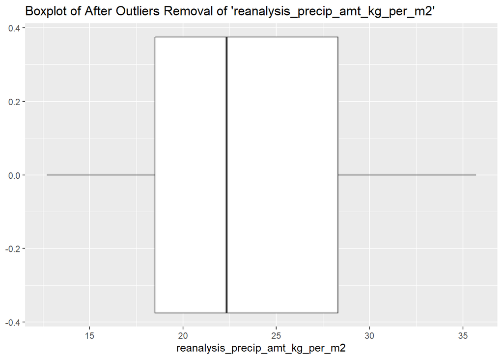

```r
box_plot_after_ol_removed <- ggplot(sj_clean_train, aes(y = reanalysis_precip_amt_kg_per_m2))
box_plot_after_ol_removed +
  geom_boxplot() +coord_flip()+ggtitle("Boxplot of After Outliers Removal of 'reanalysis_precip_amt_kg_per_m2'")
```

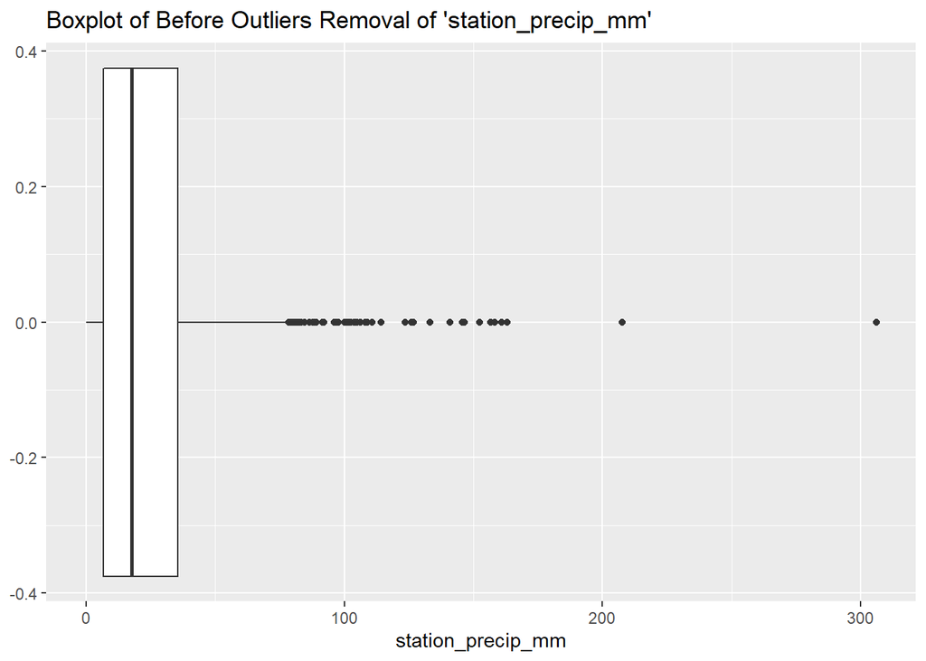

```r
box_plot_after_ol_removed <- ggplot(sj_train_features, aes(y = station_precip_mm))
box_plot_after_ol_removed +
  geom_boxplot() +coord_flip()+ggtitle("Boxplot of Before Outliers Removal of 'station_precip_mm'")
```

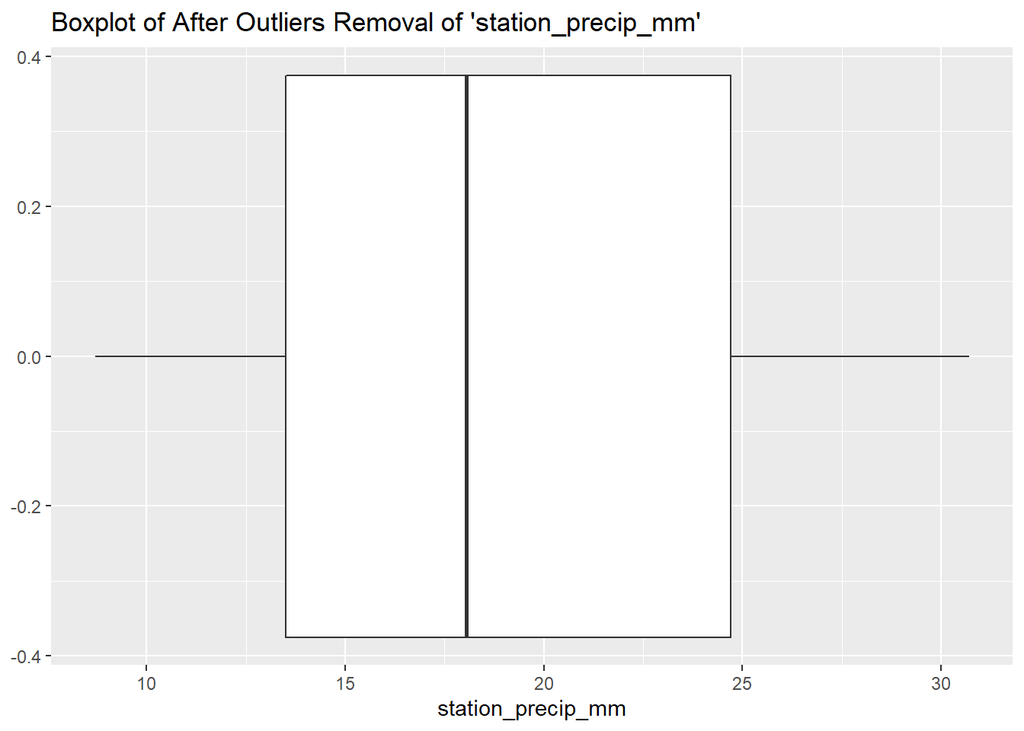

```r
box_plot_after_ol_removed <- ggplot(sj_clean_train, aes(y = station_precip_mm))
box_plot_after_ol_removed +
  geom_boxplot() +coord_flip()+ggtitle("Boxplot of After Outliers Removal of 'station_precip_mm'")
```

```r
apply(iq_train_features, 2, function(x)
  round(100 * (length(which(is.na(x))))/length(x) , digits = 1)) %>%
  as.data.frame() %>%
  `names<-`('Percent of Missing Values')
```

```
##                                       Percent of Missing Values
## city                                                        0.0
## year                                                        0.0
## weekofyear                                                  0.0
## week_start_date                                             0.0
## ndvi_ne                                                     0.6
## ndvi_nw                                                     0.6
## ndvi_se                                                     0.6
## ndvi_sw                                                     0.6
## precipitation_amt_mm                                        0.8
## reanalysis_air_temp_k                                       0.8
## reanalysis_avg_temp_k                                       0.8
## reanalysis_dew_point_temp_k                                 0.8
## reanalysis_max_air_temp_k                                   0.8
## reanalysis_min_air_temp_k                                   0.8
## reanalysis_precip_amt_kg_per_m2                             0.8
## reanalysis_relative_humidity_percent                        0.8
## reanalysis_sat_precip_amt_mm                                0.8
## reanalysis_specific_humidity_g_per_kg                       0.8
## reanalysis_tdtr_k                                           0.8
## station_avg_temp_c                                          7.1
## station_diur_temp_rng_c                                     7.1
## station_max_temp_c                                          2.7
## station_min_temp_c                                          1.5
## station_precip_mm                                           3.1
```

```r
#iq_train_features  %>%
#  summarise_all(list(~is.na(.)))%>%
#  pivot_longer(everything(),
#               names_to = "variables", values_to="missing") %>%
#  count(variables, missing) %>%
#ggplot(aes(y=variables,x=n,fill=missing))+
#  geom_col()
apply(iq_clean_train, 2, function(x)
  round(100 * (length(which(is.na(x))))/length(x) , digits = 1)) %>%
  as.data.frame() %>%
  `names<-`('Percent of Missing Values')
```

```
##                                       Percent of Missing Values
## city                                                          0
## year                                                          0
## weekofyear                                                    0
## week_start_date                                               0
## ndvi_ne                                                       0
## ndvi_nw                                                       0
## ndvi_se                                                       0
## ndvi_sw                                                       0
## precipitation_amt_mm                                          0
## reanalysis_air_temp_k                                         0
## reanalysis_avg_temp_k                                         0
## reanalysis_dew_point_temp_k                                   0
## reanalysis_max_air_temp_k                                     0
## reanalysis_min_air_temp_k                                     0
## reanalysis_precip_amt_kg_per_m2                               0
## reanalysis_relative_humidity_percent                          0
## reanalysis_sat_precip_amt_mm                                  0
## reanalysis_specific_humidity_g_per_kg                         0
## reanalysis_tdtr_k                                             0
## station_avg_temp_c                                            0
## station_diur_temp_rng_c                                       0
## station_max_temp_c                                            0
## station_min_temp_c                                            0
## station_precip_mm                                             0
## total_cases                                                   0
```

```r
#iq_clean_train  %>%
#  summarise_all(list(~is.na(.)))%>%
#  pivot_longer(everything(),
#               names_to = "variables", values_to="missing") %>%
#  count(variables, missing) %>%
#  ggplot(aes(y=variables,x=n,fill=missing))+
#  geom_col()
```

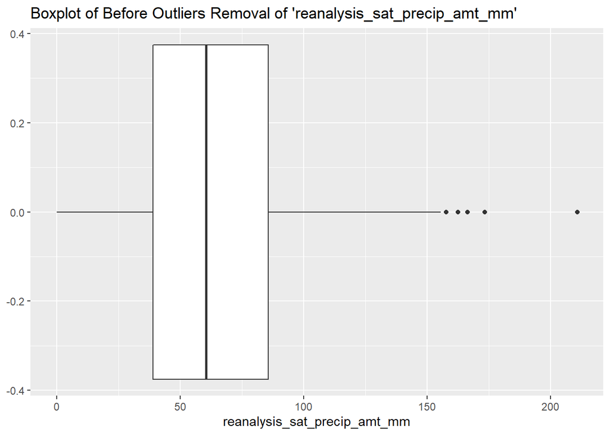

```r
box_plot_after_ol_removed <- ggplot(iq_train_features, aes(y = reanalysis_sat_precip_amt_mm))
box_plot_after_ol_removed +
  geom_boxplot() +coord_flip()+ggtitle("Boxplot of Before Outliers Removal of 'reanalysis_sat_precip_amt_mm'")
```

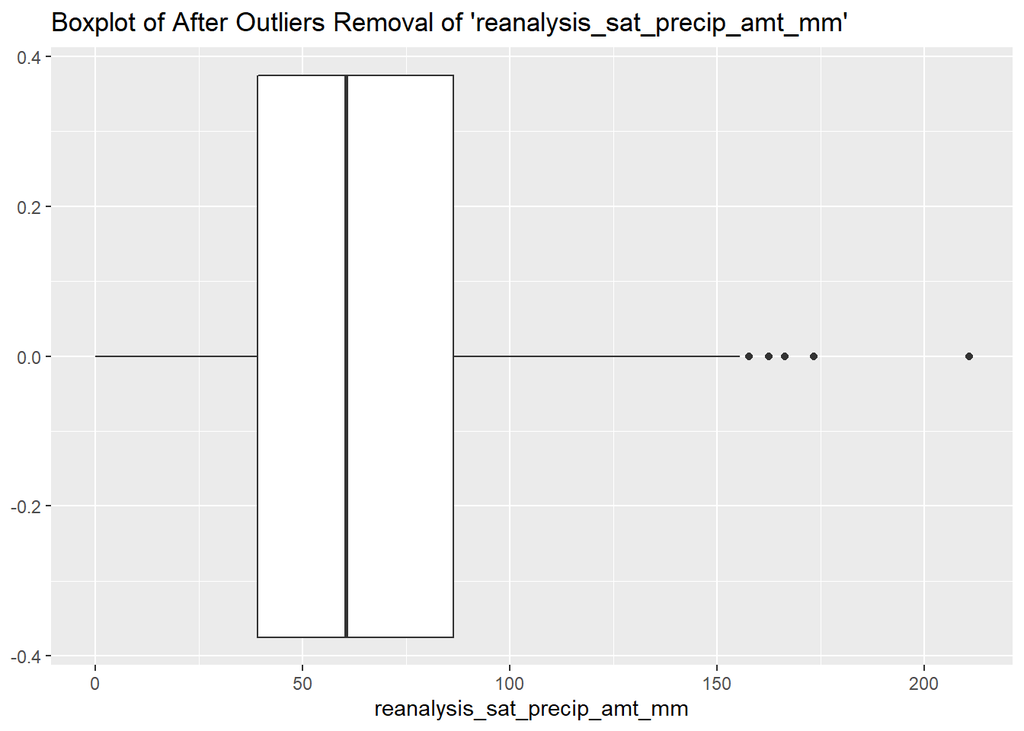

```r
box_plot_after_ol_removed <- ggplot(iq_clean_train, aes(y = reanalysis_sat_precip_amt_mm))
box_plot_after_ol_removed +
  geom_boxplot() +coord_flip()+ggtitle("Boxplot of After Outliers Removal of 'reanalysis_sat_precip_amt_mm'")
```

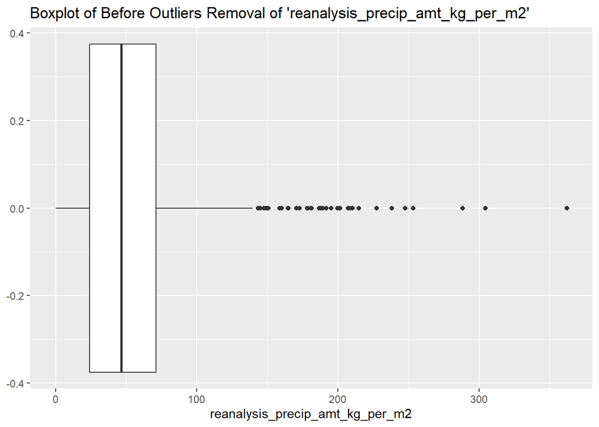

```r
box_plot_after_ol_removed <- ggplot(iq_train_features, aes(y = reanalysis_precip_amt_kg_per_m2))
box_plot_after_ol_removed +
  geom_boxplot() +coord_flip()+ggtitle("Boxplot of Before Outliers Removal of 'reanalysis_precip_amt_kg_per_m2'")
```

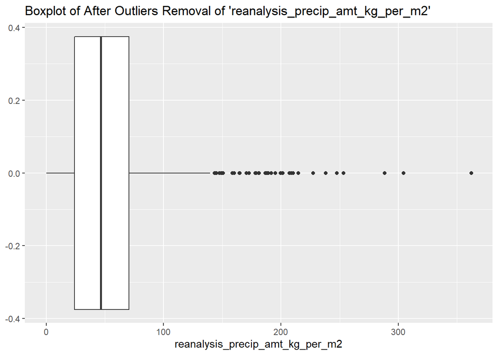

```r
box_plot_after_ol_removed <- ggplot(iq_clean_train, aes(y = reanalysis_precip_amt_kg_per_m2))
box_plot_after_ol_removed +
  geom_boxplot() +coord_flip()+ggtitle("Boxplot of After Outliers Removal of 'reanalysis_precip_amt_kg_per_m2'")
```

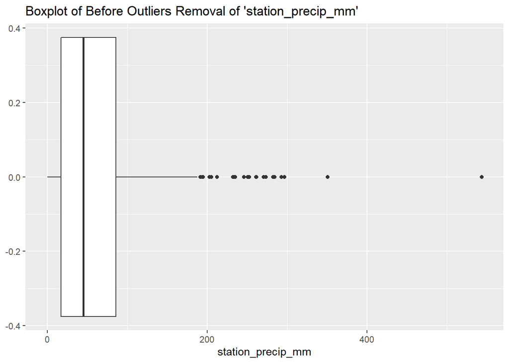

```r
box_plot_after_ol_removed <- ggplot(iq_train_features, aes(y = station_precip_mm))
box_plot_after_ol_removed +
  geom_boxplot() +coord_flip()+ggtitle("Boxplot of Before Outliers Removal of 'station_precip_mm'")
```

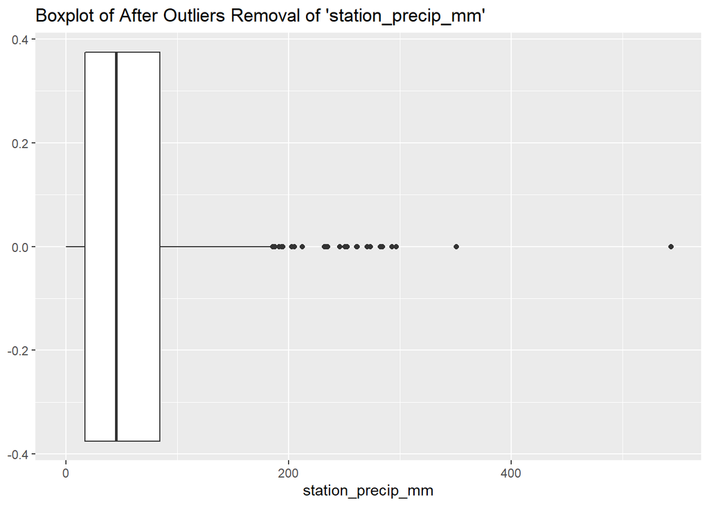

```r
box_plot_after_ol_removed <- ggplot(iq_clean_train, aes(y = station_precip_mm))
box_plot_after_ol_removed +
  geom_boxplot() +coord_flip()+ggtitle("Boxplot of After Outliers Removal of 'station_precip_mm'")
```

## Understanding ‘sj’ & ‘iq’ Data Acquired Based on Data Quantity

We can see that ‘sj’ city has more data than ‘iq’.

```r
cat('\nSan Juan\n',
    '\t features: ', sj_train_features %>% ncol,
    '\t entries: ' , sj_train_features %>% nrow,
    '\t labels: '  , sj_train_labels %>% nrow)
```

```
##
## San Juan
##       features:  24   entries:  936   labels:  936
```

```r
cat('\nIquitos\n',
    '\t features: ', iq_train_features %>% ncol,
    '\t entries: ' , iq_train_features %>% nrow,
    '\t labels: '  , iq_train_labels %>% nrow)
```

```
##
## Iquitos
##       features:  24   entries:  520   labels:  520
```

## Target Variable: ‘total_cases’

Besides from input data quantity difference between ‘sj’ & ‘iq’ data, we can see that the data distribution of target variable between 2 cities are also differnt. Hence, modelling will be done based on 2 different cities.

```r
cat('\nSan Juan\n',
    '\t total cases mean: ',      sj_train_labels$total_cases %>% mean(),
    '\t total cases variance: ' , sj_train_labels$total_cases %>% var() )
```

```
##
## San Juan
##       total cases mean:  34.18056     total cases variance:  2640.045
```

```r
cat('\nIquitos\n',
    '\t total cases mean: ',      iq_train_labels$total_cases %>% mean(),
    '\t total cases variance: ' , iq_train_labels$total_cases %>% var() )
```

```
##
## Iquitos
##       total cases mean:  7.565385     total cases variance:  115.8955
```

## Target Variable: ‘total_cases’ Period

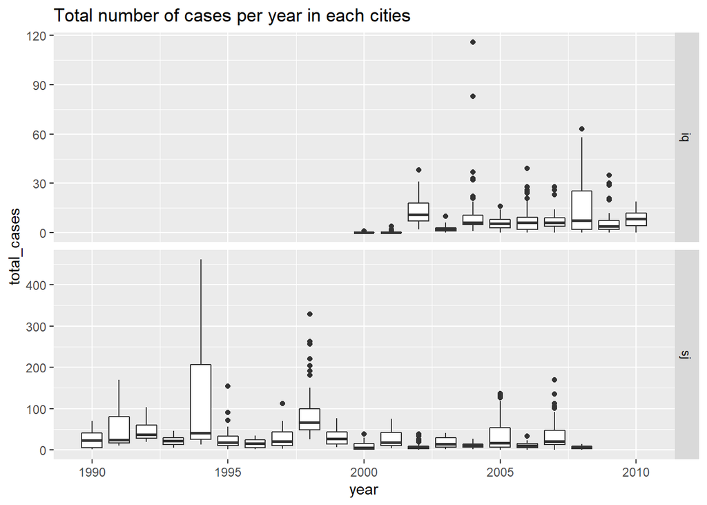

```r
train_cleaned %>% ggplot() +
  geom_boxplot(aes(year, total_cases, group=year)) +
  facet_grid(city ~ ., scale = "free") +
  ggtitle("Total number of cases per year in each cities")
```

## Target Variable: ‘total_cases’ Distribution

Although statistical information and period of ‘total_cases’ in 2 different cities are different, however, the distribution of the data are similar across 2 different cities. Although the distribution size across 2 different cities are similar, the nature of data acquired have different maximum values where we can see ‘sj’ data has higher range of data across 0 - 500.

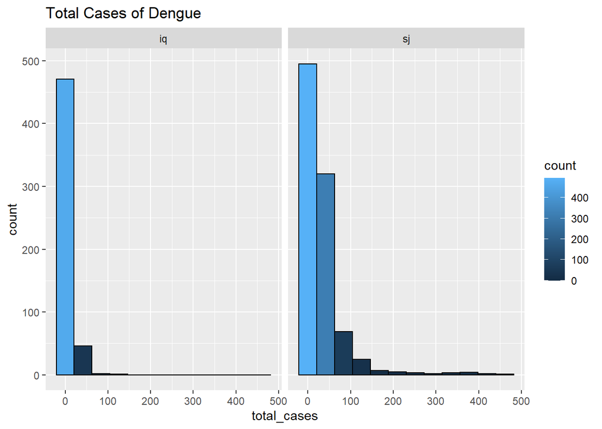

```r
rbind(iq_train_labels, sj_train_labels) %>%
  ggplot(aes(x = total_cases,fill = ..count..)) +
  geom_histogram(bins = 12, colour = 'black') + ggtitle('Total Cases of Dengue') +
  scale_y_continuous(breaks = seq(0,700,100)) + facet_wrap(~city)
```

## Creating Correlation Plot of ‘sj’ City

We can see that from all the input features, they do not have high correlation, either positive or negative with target variable, ‘total_cases’, as we see the correlation value does not go over 50%.

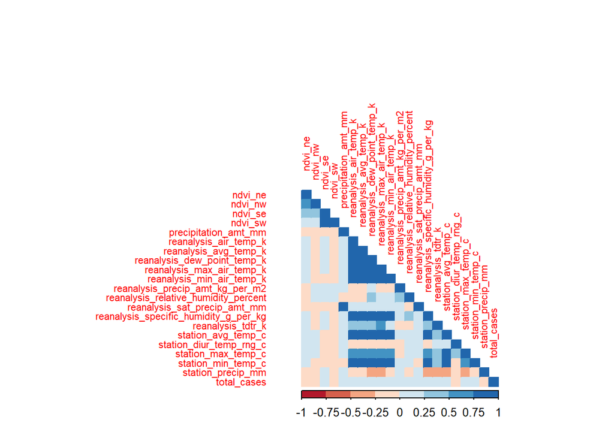

```r
sj_clean_train %>%
  dplyr::select(-city, -year, -weekofyear, -week_start_date) %>%
  cor(use = 'pairwise.complete.obs') -> M1
corrplot(M1, type="lower", method="color",
           col=brewer.pal(n=8, name="RdBu"), tl.cex=0.7, tl.offset=2)
```

## Creating Correlation Plot of ‘iq’ City

Same goes to ‘iq’ city, We can see that from all the input features, they do not have high correlation, either positive or negative with target variable, ‘total_cases’, as we see the correlation value does not go over 50%.

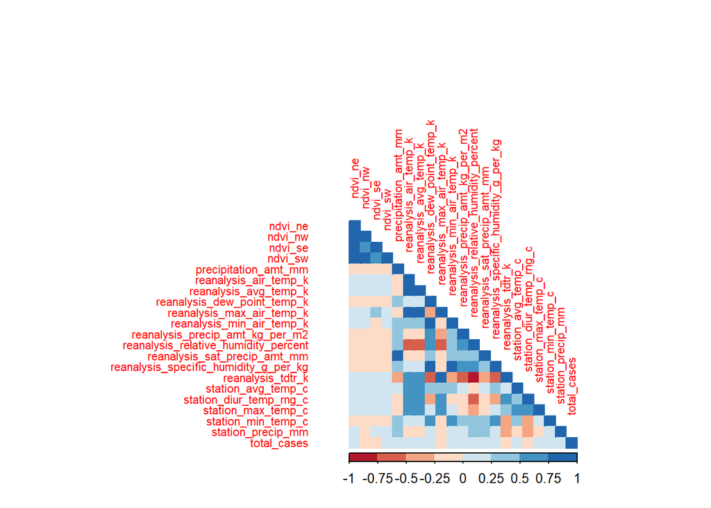

```r
iq_clean_train %>%
  dplyr::select(-city, -year, -weekofyear, -week_start_date) %>%
  cor(use = 'pairwise.complete.obs') -> M2
corrplot(M2, type="lower", method="color",
           col=brewer.pal(n=8, name="RdBu"), tl.cex=0.7, tl.offset=2)
```

## Creating Correlation Barplot of 2 Cities, on ‘sj’ & ‘iq’

Even though the target variable, ‘total_cases’ in both cities have same distribution, however, they have different highest correlated features. This may due to data statistical different between 2 cities. In ‘sj’ city, the most positive relation feature with ‘total_cases’ are ‘station_min_temp_c’ & ‘station_avg_temp_c’, while the highest negative correlated feature would be ‘ndvi_ne’. In contrast, in ‘iq’ city, the most positive relation feature with ‘total_cases’ are ‘reanalysis_specific_humidity_g_per_kg’ & ‘reanalysis_dew_point_temp_k’, while the highest negative correlated feature would be ‘reanalysis_tdtr_k’. All these highest positive and negative correlated features do not have relationship over 50%.

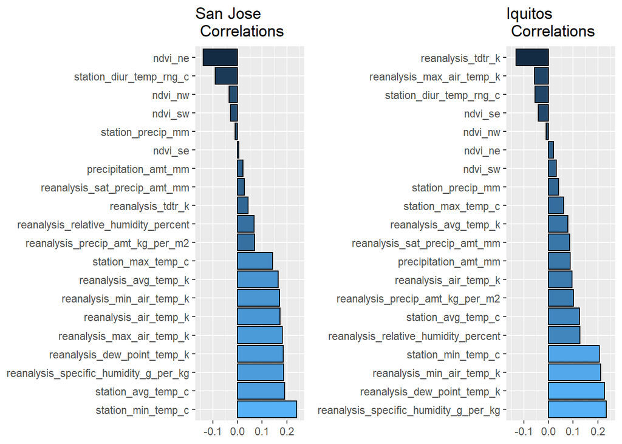

```r
sort(M1[21,-21]) %>%
  as.data.frame %>%
  `names<-`('correlation') %>%
  ggplot(aes(x = reorder(row.names(.), -correlation), y = correlation, fill = correlation)) +
  geom_bar(stat='identity', colour = 'black') + scale_fill_continuous(guide = FALSE) + scale_y_continuous(limits =  c(-.15,.25)) +
  labs(title = 'San Jose\n Correlations', x = NULL, y = NULL) + coord_flip() -> cor1
# can use ncol(M1) instead of 21 to generalize the code
sort(M2[21,-21]) %>%
  as.data.frame %>%
  `names<-`('correlation') %>%
  ggplot(aes(x = reorder(row.names(.), -correlation), y = correlation, fill = correlation)) +
  geom_bar(stat='identity', colour = 'black') + scale_fill_continuous(guide = FALSE) + scale_y_continuous(limits =  c(-.15,.25)) +
  labs(title = 'Iquitos\n Correlations', x = NULL, y = NULL) + coord_flip() -> cor2
grid.arrange(cor1, cor2, nrow = 1)
```

## Creating Line Plot to Understand the Highest Correlated Features to ‘total_cases’ in ‘sj’

Now we can see that the data are not correlated well with ‘total_cases’ across time. This may due to the scale between the data or, the data are not highly correlated. Scaling is suggested for modelling stage later on the input features to match the data distribution.

[figure not shown]

```r
ggplot()+
  geom_line(data=sj_clean_train, mapping=aes(week_start_date, station_min_temp_c), color='blue') +
  geom_line(data=sj_clean_train, mapping=aes(week_start_date, total_cases), color='red') +
  ggtitle("Reanalysis_Specific_Humidity_g_per_kg vs Total_Cases over Time")
```

[figure not shown]

```r
ggplot()+
  geom_line(data=sj_clean_train, mapping=aes(week_start_date, station_avg_temp_c), color='blue') +
  geom_line(data=sj_clean_train, mapping=aes(week_start_date, total_cases), color='red') +
  ggtitle("Reanalysis_Specific_Humidity_g_per_kg vs Total_Cases over Time")
```

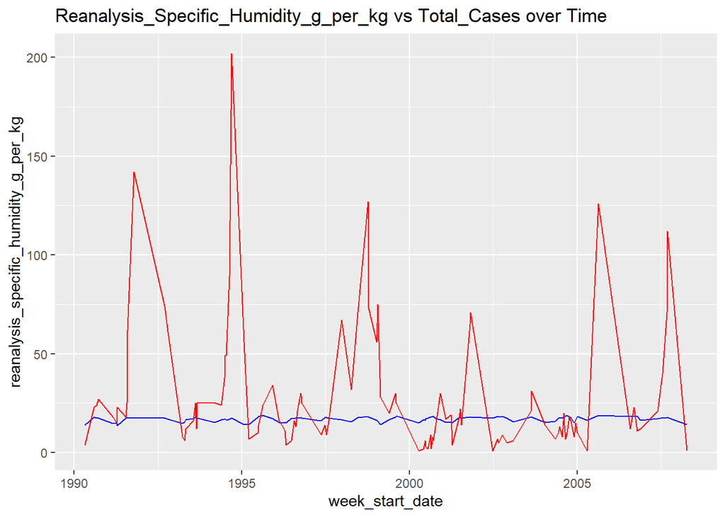

```r
ggplot()+
  geom_line(data=sj_clean_train, mapping=aes(week_start_date, reanalysis_specific_humidity_g_per_kg), color='blue') +
  geom_line(data=sj_clean_train, mapping=aes(week_start_date, total_cases), color='red') +
  ggtitle("Reanalysis_Specific_Humidity_g_per_kg vs Total_Cases over Time")
```

## Creating Line Plot to Understand the Highest Correlated Features to ‘total_cases’ in iq’

Now we can see that the data are not correlated well with ‘total_cases’ across time. This may due to the scale between the data or, the data are not highly correlated. Scaling is suggested for modelling stage later on the input features to match the data distribution.

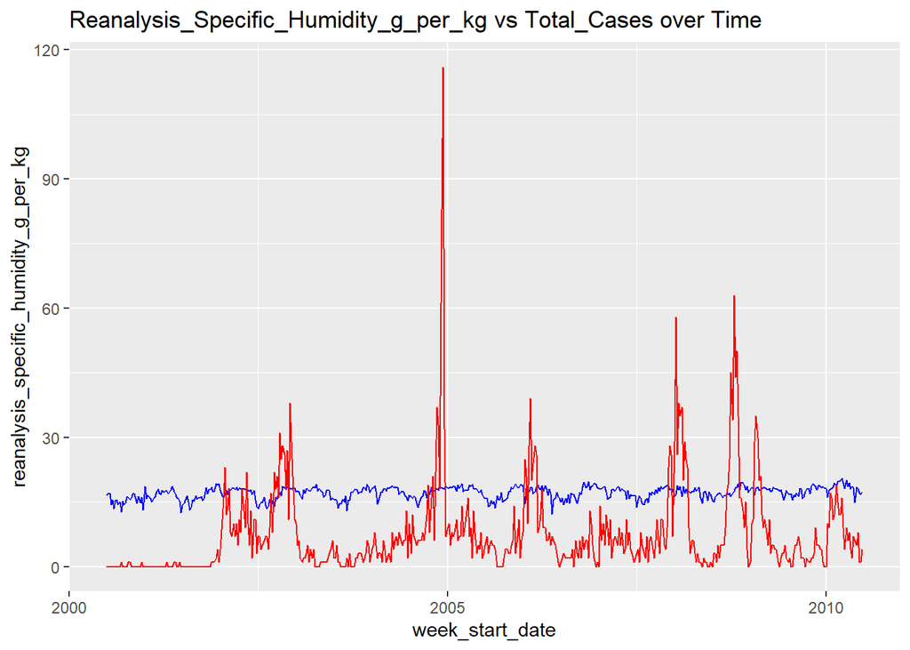

```r
ggplot()+
  geom_line(data=iq_clean_train, mapping=aes(week_start_date, reanalysis_specific_humidity_g_per_kg), color='blue') +
  geom_line(data=iq_clean_train, mapping=aes(week_start_date, total_cases), color='red') +
  ggtitle("Reanalysis_Specific_Humidity_g_per_kg vs Total_Cases over Time")
```

[figure not shown]

```r
ggplot()+
  geom_line(data=iq_clean_train, mapping=aes(week_start_date, reanalysis_dew_point_temp_k), color='blue') +
  geom_line(data=iq_clean_train, mapping=aes(week_start_date, total_cases), color='red') +
  ggtitle("Reanalysis_Specific_Humidity_g_per_kg vs Total_Cases over Time")
```

[figure not shown]

```r
ggplot()+
  geom_line(data=iq_clean_train, mapping=aes(week_start_date, reanalysis_tdtr_k), color='blue') +
  geom_line(data=iq_clean_train, mapping=aes(week_start_date, total_cases), color='red') +
  ggtitle("Reanalysis_Specific_Humidity_g_per_kg vs Total_Cases over Time")
```

## Classification Model (By Loh Cin Ceat)

# Classification of Dengue Outbreak

The aims of this section is to predict the occurrence of dengue outbreak by using classification models of support-vector machines (SVM) model with polynomial kernel function and random forest model.According to the WHO, a dengue outbreak is a period of time in which a reported case of a week is more than the sum of the moving average of three 4-week dengue cases plus the value of two standard deviations above the number of dengue cases for the cases four weeks prior.

## Dengue Outbreak Variable Calculation

The target variable (outbreak) indicates whether there was a dengue outbreak in a particular week-of-the-year in each city. The dengue outbreak variable (Yes = Dengue Outbreak, No= No dengue outbreak) was created based on the original variable of reported number of dengue cases.To compute the outbreak variable few steps of calculation have to be made.

1. The average number of dengue cases during the previous four weeks is computed.
2. The value for the two-standard deviations for four average number of dengue case the previously calculated is determined .
3. The moving average of three 4 week mean dengue cases is then computed.
4. The sum of the moving averages of the three, four-week dengue cases plus the two standard deviations of dengue cases for the previous four weeks is computed .
5. If the weekly instances exceed 2 cases of dengue and the figure calculated in step 4, an epidemic has most likely occurred.

After calculation, the new dataset is shown as below.

```r
df <- read.csv("https://github.com/KewJS/wqd7004-dengai/raw/main/data/Train_cleaned_Outbreak_.csv")
head(df,5)
```

```
##   city year weekofyear week_start_date   ndvi_ne   ndvi_nw   ndvi_se   ndvi_sw
## 1   iq 2000         26        1/7/2000 0.1928857 0.1322571 0.3408857 0.2472000
## 2   iq 2000         27        8/7/2000 0.2168333 0.2761000 0.2894571 0.2416571
## 3   iq 2000         28       15/7/2000 0.1767571 0.1731286 0.2041143 0.1280143
## 4   iq 2000         29       22/7/2000 0.2277286 0.1454286 0.2542000 0.2003143
## 5   iq 2000         30       29/7/2000 0.3286429 0.3221286 0.2543714 0.3610429
##   precipitation_amt_mm reanalysis_air_temp_k reanalysis_avg_temp_k
## 1                25.41              296.7400              298.4500
## 2                60.61              296.6343              298.4286
## 3                55.52              296.4157              297.3929
## 4                 5.60              295.3571              296.2286
## 5                62.76              296.4329              297.6357
##   reanalysis_dew_point_temp_k reanalysis_max_air_temp_k
## 1                    295.1843                     307.3
## 2                    295.3586                     306.6
```

[output cut: 39 more lines]

## Data Preprocessing Before Applying Model

Before applying the data into model for prediction, the data is preprocessed by spliting the deleted unrelated variables and splitting the data according to the city.

1. Delete the Variable used to determine the occurrence of outbreak.

```r
df = subset(df, select = -c(`X4wkly.average`,`X2SD.4wkly.Avg`,`Avg.of.3.4wkly.mean`,`Avg.of.3.4wkly.mean.2sd.of.4wkly.mean`) )
```

2. Split the data according to the city

```r
iq_df<- df[which(df$city=="iq"),]
sj_df<- df[which(df$city=="sj"),]
```

3. Delete the unrelated variable for prediction for both data of each city.

```r
iq_df<-iq_df[-c(1:6),]
iq_df<-subset(iq_df,select = -c(1,2,3,4))
head(iq_df,5)
```

```
##      ndvi_ne   ndvi_nw   ndvi_se   ndvi_sw precipitation_amt_mm
## 7  0.3124857 0.3299857 0.3805857 0.3872714                89.37
## 8  0.3841333 0.3922400 0.3417800 0.3827500                42.08
## 9  0.4081571 0.3221571 0.4067143 0.3027143                49.22
## 10 0.3320429 0.3210571 0.3146143 0.3242571                53.65
## 11 0.2955857 0.2956833 0.3122143 0.2659286                23.12
##    reanalysis_air_temp_k reanalysis_avg_temp_k reanalysis_dew_point_temp_k
## 7               297.3200              298.9786                    293.8214
## 8               297.6271              299.3357                    293.9929
## 9               298.2386              299.5714                    292.9043
## 10              299.2186              300.9286                    293.4729
## 11              300.8029              301.9357                    290.6357
##    reanalysis_max_air_temp_k reanalysis_min_air_temp_k
## 7                      308.8                     292.1
## 8                      307.9                     290.6
```

[output cut: 27 more lines]

```r
sj_df<-sj_df[-c(1:6),]
sj_df<-subset(sj_df,select = -c(1,2,3,4))
head(sj_df,5)
```

```
##      ndvi_ne  ndvi_nw   ndvi_se   ndvi_sw precipitation_amt_mm
## 527 0.112900 0.092800 0.2050714 0.2102714                 3.48
## 528 0.072500 0.072500 0.1514714 0.1330286               151.12
## 529 0.102450 0.146175 0.1255714 0.1236000                19.32
## 530 0.119400 0.121550 0.1606833 0.2025667                14.41
## 531 0.192875 0.082350 0.1919429 0.1529286                22.27
##     reanalysis_air_temp_k reanalysis_avg_temp_k reanalysis_dew_point_temp_k
## 527              299.2071              299.2214                    295.8657
## 528              299.5914              299.5286                    296.5314
## 529              299.5786              299.5571                    296.3786
## 530              300.1543              300.2786                    296.6514
## 531              299.5129              299.5929                    296.0414
##     reanalysis_max_air_temp_k reanalysis_min_air_temp_k
## 527                     301.3                     297.7
## 528                     300.6                     298.4
```

[output cut: 33 more lines]

```r
table(iq_df$Outbreak)
```

```
##
##  No Yes
## 397 117
```

```r
table(sj_df$Outbreak)
```

```
##
##  No Yes
## 676 254
```

## Simple Random Under Sampling

```r
## rows that have "Yes" and "No" entries
iq_Yes <- which(iq_df$Outbreak == "Yes")
iq_No <- which(iq_df$Outbreak == "No")


nsamp <- length(iq_Yes)

set.seed(100)

# a random sample of "No" is picked based on the number of "Yes" in the Outbreak variable.
pick_iq_No<-sample(iq_No, nsamp)
iq_df <- iq_df[c(pick_iq_No,iq_Yes), ]

# Final balanced data
table(iq_df$Outbreak)
```

```
##
##  No Yes
## 117 117
```

```r
## rows that have "Yes" and "No" entries
sj_Yes <- which(sj_df$Outbreak == "Yes")
sj_No <- which(sj_df$Outbreak == "No")


nsamp <- length(sj_Yes)
set.seed(100)

# a random sample of "No" is picked based on the number of "Yes" in the Outbreak variable.
pick_sj_No<-sample(sj_No, nsamp)
sj_df <- sj_df[c(pick_sj_No,sj_Yes), ]

# Final balanced data
table(sj_df$Outbreak)
```

```
##
##  No Yes
## 254 254
```

## Splitting data to train and test split

The data set for each city is split according to 80% training set and 20% testing set to apply for the models for predicting.

```r
# To achieve reproducible model; set the random seed number
set.seed(100)

# Performs stratified random split of the data set
iq_TrainingIndex <- createDataPartition(iq_df$Outbreak, p=0.8, list = FALSE)
iq_TrainingSet <- iq_df[iq_TrainingIndex,] # Training Set
iq_TestingSet <- iq_df[-iq_TrainingIndex,] # Test Set

sj_TrainingIndex <- createDataPartition(sj_df$Outbreak, p=0.8, list = FALSE)
sj_TrainingSet <- sj_df[sj_TrainingIndex,] # Training Set
sj_TestingSet <- sj_df[-sj_TrainingIndex,] # Test Set
```

## SVM model with polynomial kernel function

support-vector machines (SVM) model with polynomial kernel function with 10 fold cross validation is build to make prediction of dengue outbreak on the training and testing set of both Iquitos and San Juan city.

```r
###############################
# SVM model (polynomial kernel)for Iquitos


iq_TrainingSet$Outbreak<- factor(iq_TrainingSet$Outbreak)  ### must do this to prevent error
iq_TestingSet$Outbreak<- factor(iq_TestingSet$Outbreak)


# Build CV model
iq_Model <- train(Outbreak ~ ., data = iq_TrainingSet,
                  method = "svmPoly",
                  na.action = na.omit,
                  preProcess=c("scale","center"),
                  trControl= trainControl(method="cv", number=10),
                  tuneLength = 4
)
summary(iq_Model)
```

```
## Length  Class   Mode
##      1   ksvm     S4
```

```r
# Apply model for prediction
iq_Model.training <-predict(iq_Model, iq_TrainingSet) # Apply model to make prediction on Training set



iq_Model.testing <-predict(iq_Model, iq_TestingSet) # Apply model to make prediction on Testing set
```

```r
###############################
# SVM model (polynomial kernel) for San Juan

# Build Training model
sj_TrainingSet$Outbreak<- factor(sj_TrainingSet$Outbreak)  ### must do this to prevent error
sj_TestingSet$Outbreak<- factor(sj_TestingSet$Outbreak)


# Build SVM model
sj_Model <- train(Outbreak ~ ., data = sj_TrainingSet,
                  method = "svmPoly",
                  na.action = na.omit,
                  preProcess=c("scale","center"),
                  trControl= trainControl(method="cv", number=10),
                  tuneLength = 4
)
summary(sj_Model)
```

```
## Length  Class   Mode
##      1   ksvm     S4
```

```r
# Apply model for prediction
sj_Model.training <-predict(sj_Model, sj_TrainingSet) # Apply model to make prediction on Training set

sj_Model.testing <-predict(sj_Model, sj_TestingSet) # Apply model to make prediction on Testing set
```

## Random Forest Model

Random forest classification model with 10 fold cross validation is build to make prediction of dengue outbreak on the training and testing set of both Iquitos and San Juan city.

```r
###############################
# Random forest model for Iquitos

# Build CV model
mtry <- sqrt(ncol(iq_TrainingSet))
iq_Model.rf <- train(Outbreak ~ ., data = iq_TrainingSet,
                    method='rf',
                    metric='Accuracy',
                    tuneGrid=expand.grid(.mtry=mtry),
                    trControl=trainControl(method='repeatedcv',number=10,repeats=3)
)

summary(iq_Model.rf)
```

```
##                 Length Class      Mode
## call               4   -none-     call
## type               1   -none-     character
## predicted        188   factor     numeric
## err.rate        1500   -none-     numeric
## confusion          6   -none-     numeric
## votes            376   matrix     numeric
## oob.times        188   -none-     numeric
## classes            2   -none-     character
## importance        21   -none-     numeric
## importanceSD       0   -none-     NULL
## localImportance    0   -none-     NULL
## proximity          0   -none-     NULL
## ntree              1   -none-     numeric
## mtry               1   -none-     numeric
## forest            14   -none-     list
## y                188   factor     numeric
## test               0   -none-     NULL
## inbag              0   -none-     NULL
## xNames            21   -none-     character
## problemType        1   -none-     character
## tuneValue          1   data.frame list
## obsLevels          2   -none-     character
## param              0   -none-     list
```

```r
# Apply model for prediction
iq_Model.training.rf <-predict(iq_Model.rf, iq_TrainingSet) # Apply model to make prediction on Training set

iq_Model.testing.rf <-predict(iq_Model.rf, iq_TestingSet) # Apply model to make prediction on Testing set
```

```r
###############################
# Random forest model for for San Juan


# Build CV model

mtry <- sqrt(ncol(sj_TrainingSet))
sj_Model.rf <- train(Outbreak ~ ., data = sj_TrainingSet,
                    method='rf',
                    metric='Accuracy',
                    tuneGrid=expand.grid(.mtry=mtry),
                    trControl=trainControl(method='repeatedcv',number=10,repeats=3)
)

summary(sj_Model.rf)%>%
  kable() %>%
  kable_styling()
```

|  | Length | Class | Mode |
| --- | --- | --- | --- |
| call | 4 | -none- | call |
| type | 1 | -none- | character |
| predicted | 408 | factor | numeric |
| err.rate | 1500 | -none- | numeric |
| confusion | 6 | -none- | numeric |
| votes | 816 | matrix | numeric |
| oob.times | 408 | -none- | numeric |
| classes | 2 | -none- | character |
| importance | 21 | -none- | numeric |
| importanceSD | 0 | -none- | NULL |
| localImportance | 0 | -none- | NULL |
| proximity | 0 | -none- | NULL |
| ntree | 1 | -none- | numeric |
| mtry | 1 | -none- | numeric |
| forest | 14 | -none- | list |
| y | 408 | factor | numeric |
| test | 0 | -none- | NULL |
| inbag | 0 | -none- | NULL |
| xNames | 21 | -none- | character |
| problemType | 1 | -none- | character |
| tuneValue | 1 | data.frame | list |
| obsLevels | 2 | -none- | character |
| param | 0 | -none- | list |

```r
# Apply model for prediction
sj_Model.training.rf <-predict(sj_Model.rf, sj_TrainingSet) # Apply model to make prediction on Training set

sj_Model.testing.rf <-predict(sj_Model.rf, sj_TestingSet) # Apply model to make prediction on Testing set
```

## Model Evaluation

### Support Vector Machines with Polynomial Kernel

```r
# Model performance for Iquitos (Displays confusion matrix and statistics)
iq_Model.training.confusion <-confusionMatrix(iq_Model.training, iq_TrainingSet$Outbreak,positive = "Yes" )
iq_Model.testing.confusion <-confusionMatrix(iq_Model.testing, iq_TestingSet$Outbreak,positive = "Yes" )

# Training set
iq_Model.train.mat <- iq_Model.training.confusion$table
iq_Model.train.acc <- iq_Model.training.confusion$overall['Accuracy']
iq_Model.train.sens <- iq_Model.training.confusion$byClass['Sensitivity']
iq_Model.train.spec <- iq_Model.training.confusion$byClass['Specificity']

# Testing set
iq_Model.test.mat <- iq_Model.testing.confusion$table
iq_Model.test.acc <- iq_Model.testing.confusion$overall['Accuracy']
iq_Model.test.sens <- iq_Model.testing.confusion$byClass['Sensitivity']
iq_Model.test.spec <- iq_Model.testing.confusion$byClass['Specificity']

# Model performance for San Juan (Displays confusion matrix and statistics)
sj_Model.training.confusion <-confusionMatrix(sj_Model.training, sj_TrainingSet$Outbreak,,positive = "Yes")
sj_Model.testing.confusion <-confusionMatrix(sj_Model.testing, sj_TestingSet$Outbreak,,positive = "Yes")

# Training set
sj_Model.train.mat <- sj_Model.training.confusion$table
sj_Model.train.acc <- sj_Model.training.confusion$overall['Accuracy']
sj_Model.train.sens <- sj_Model.training.confusion$byClass['Sensitivity']
sj_Model.train.spec <- sj_Model.training.confusion$byClass['Specificity']

# Testing set
sj_Model.test.mat <- sj_Model.testing.confusion$table
sj_Model.test.acc <- sj_Model.testing.confusion$overall['Accuracy']
sj_Model.test.sens <- sj_Model.testing.confusion$byClass['Sensitivity']
sj_Model.test.spec <- sj_Model.testing.confusion$byClass['Specificity']
```

## Confusion matrix

### Iquitos

```r
# Training set
iq_Model.train.mat
```

```
##           Reference
## Prediction No Yes
##        No  77  25
##        Yes 17  69
```

The confusion matrix shows 77+69 = 146 correct predictions and 25+17= 42 incorrect ones.

```r
# Testing set
iq_Model.test.mat
```

```
##           Reference
## Prediction No Yes
##        No  16   9
##        Yes  7  14
```

The confusion matrix shows 16+14 = 30 correct predictions and 9+7= 16 incorrect ones.

### san Juan

```r
# Training set
sj_Model.train.mat
```

```
##           Reference
## Prediction  No Yes
##        No  107  49
##        Yes  97 155
```

The confusion matrix shows 107+155 = 262 correct predictions and 49+97= 146 incorrect ones.

```r
# Testing set
sj_Model.test.mat
```

```
##           Reference
## Prediction No Yes
##        No  29  11
##        Yes 21  39
```

The confusion matrix shows 39+29 = 68 correct predictions and 11+21= 32 incorrect ones.

## Model Evaluation - Statistics

### Iquitos

```r
# Training set
iq_Model.train.acc <- iq_Model.training.confusion$overall['Accuracy']
iq_Model.train.sens <- iq_Model.training.confusion$byClass['Sensitivity']
iq_Model.train.spec <- iq_Model.training.confusion$byClass['Specificity']


# Testing set
iq_Model.test.acc <- iq_Model.testing.confusion$overall['Accuracy']
iq_Model.test.sens <- iq_Model.testing.confusion$byClass['Sensitivity']
iq_Model.test.spec <- iq_Model.testing.confusion$byClass['Specificity']
```

### San Juan

```r
# Training set
sj_Model.train.acc <- sj_Model.training.confusion$overall['Accuracy']
sj_Model.train.sens <- sj_Model.training.confusion$byClass['Sensitivity']
sj_Model.train.spec <- sj_Model.training.confusion$byClass['Specificity']


#Testing Set
sj_Model.test.acc <- sj_Model.testing.confusion$overall['Accuracy']
sj_Model.test.sens <- sj_Model.testing.confusion$byClass['Sensitivity']
sj_Model.test.spec <- sj_Model.testing.confusion$byClass['Specificity']
```

### Summary of the Statistic of SVM poly Model

```r
acc_tbl<-tibble(Model='SVM Poly',
                Set= c("iq_TrainingSet", "iq_TestingSet","sj_TrainingSet", "sj_TestingSet"),
                Accuracy=c(iq_Model.train.acc,iq_Model.test.acc,sj_Model.train.acc,sj_Model.test.acc),
                Sensitivity = c(iq_Model.train.sens,iq_Model.test.sens,sj_Model.train.sens,sj_Model.test.sens),
                Specificity = c(iq_Model.train.spec,iq_Model.test.spec,sj_Model.train.spec,sj_Model.test.spec))
acc_tbl
```

```
## # A tibble: 4 x 5
##   Model    Set            Accuracy Sensitivity Specificity
##   <chr>    <chr>             <dbl>       <dbl>       <dbl>
## 1 SVM Poly iq_TrainingSet    0.777       0.734       0.819
## 2 SVM Poly iq_TestingSet     0.652       0.609       0.696
## 3 SVM Poly sj_TrainingSet    0.642       0.760       0.525
## 4 SVM Poly sj_TestingSet     0.68        0.78        0.58
```

## Random Forest

```r
# Model performance (Displays confusion matrix and statistics)
iq_Model.training.confusion.rf <-confusionMatrix(iq_Model.training.rf, iq_TrainingSet$Outbreak,positive = "Yes")
iq_Model.testing.confusion.rf <-confusionMatrix(iq_Model.testing.rf, iq_TestingSet$Outbreak,positive = "Yes")


# Training set
iq_Model.train.mat.rf <- iq_Model.training.confusion.rf$table
iq_Model.train.acc.rf <- iq_Model.training.confusion.rf$overall['Accuracy']
iq_Model.train.sens.rf <- iq_Model.training.confusion.rf$byClass['Sensitivity']
iq_Model.train.spec.rf <- iq_Model.training.confusion.rf$byClass['Specificity']

# Testing set
iq_Model.test.mat.rf <- iq_Model.testing.confusion.rf$table
iq_Model.test.acc.rf <- iq_Model.testing.confusion.rf$overall['Accuracy']
iq_Model.test.sens.rf <- iq_Model.testing.confusion.rf$byClass['Sensitivity']
iq_Model.test.spec.rf <- iq_Model.testing.confusion.rf$byClass['Specificity']

# Model performance for San Juan (Displays confusion matrix and statistics)
sj_Model.training.confusion.rf <-confusionMatrix(sj_Model.training.rf, sj_TrainingSet$Outbreak,,positive = "Yes")
sj_Model.testing.confusion.rf <-confusionMatrix(sj_Model.testing.rf, sj_TestingSet$Outbreak,,positive = "Yes")

# Training set
sj_Model.train.mat.rf <- sj_Model.training.confusion.rf$table
sj_Model.train.acc.rf <- sj_Model.training.confusion.rf$overall['Accuracy']
sj_Model.train.sens.rf <- sj_Model.training.confusion.rf$byClass['Sensitivity']
sj_Model.train.spec.rf <- sj_Model.training.confusion.rf$byClass['Specificity']

# Testing set
sj_Model.test.mat.rf <- sj_Model.testing.confusion.rf$table
sj_Model.test.acc.rf <- sj_Model.testing.confusion.rf$overall['Accuracy']
sj_Model.test.sens.rf <- sj_Model.testing.confusion.rf$byClass['Sensitivity']
sj_Model.test.spec.rf <- sj_Model.testing.confusion.rf$byClass['Specificity']
```

## Confusion matrix

### Iquitos

```r
# Training set
iq_Model.train.mat.rf
```

```
##           Reference
## Prediction No Yes
##        No  94   0
##        Yes  0  94
```

The confusion matrix shows 94+94 = 188 correct predictions and no incorrect ones.

True Positives: 94 True Negatives: 94 False Positives: 0 (Type I error) False Negatives: 0 ( Type II error)

```r
# Testing set
iq_Model.test.mat.rf
```

```
##           Reference
## Prediction No Yes
##        No  10   3
##        Yes 13  20
```

The confusion matrix shows 10+20 = 30 correct predictions and 3+13= 16 incorrect ones.

### san Juan

```r
# Training set
sj_Model.train.mat.rf
```

```
##           Reference
## Prediction  No Yes
##        No  204   0
##        Yes   0 204
```

The confusion matrix shows 204+204 = 408 correct predictions and no incorrect ones.

True Positives: 204 True Negatives: 204 False Positives: 0 (Type I error) False Negatives: 0 ( Type II error)

```r
# Testing set
sj_Model.test.mat.rf
```

```
##           Reference
## Prediction No Yes
##        No  35  13
##        Yes 15  37
```

The confusion matrix shows 35+37 = 72 correct predictions and 13+15= 28 incorrect ones.

## Model Evaluation - Statistics

### Iquitos

```r
# Training set
iq_Model.train.acc.rf <- iq_Model.training.confusion.rf$overall['Accuracy']
iq_Model.train.sens.rf <- iq_Model.training.confusion.rf$byClass['Sensitivity']
iq_Model.train.spec.rf <- iq_Model.training.confusion.rf$byClass['Specificity']


# Testing set
iq_Model.test.acc.rf <- iq_Model.testing.confusion.rf$overall['Accuracy']
iq_Model.test.sens.rf <- iq_Model.testing.confusion.rf$byClass['Sensitivity']
iq_Model.test.spec.rf <- iq_Model.testing.confusion.rf$byClass['Specificity']
```

### san Juan

```r
# Training set
sj_Model.train.acc.rf <- sj_Model.training.confusion.rf$overall['Accuracy']
sj_Model.train.sens.rf <- sj_Model.training.confusion.rf$byClass['Sensitivity']
sj_Model.train.spec.rf <- sj_Model.training.confusion.rf$byClass['Specificity']


#Testing Set
sj_Model.test.acc.rf <- sj_Model.testing.confusion.rf$overall['Accuracy']
sj_Model.test.sens.rf <- sj_Model.testing.confusion.rf$byClass['Sensitivity']
sj_Model.test.spec.rf <- sj_Model.testing.confusion.rf$byClass['Specificity']
```

```r
acc_tbl.rf<-tibble(Model='Random Forest',
                Set= c("iq_TrainingSet", "iq_TestingSet","sj_TrainingSet", "sj_TestingSet"),
                Accuracy=c(iq_Model.train.acc.rf,iq_Model.test.acc.rf,sj_Model.train.acc.rf,sj_Model.test.acc.rf),
                Sensitivity = c(iq_Model.train.sens.rf,iq_Model.test.sens.rf,sj_Model.train.sens.rf,sj_Model.test.sens.rf),
                Specificity = c(iq_Model.train.spec.rf,iq_Model.test.spec.rf,sj_Model.train.spec.rf,sj_Model.test.spec.rf))

summary(acc_tbl.rf)
```

```
##     Model               Set               Accuracy       Sensitivity
##  Length:4           Length:4           Min.   :0.6522   Min.   :0.7400
##  Class :character   Class :character   1st Qu.:0.7030   1st Qu.:0.8372
##  Mode  :character   Mode  :character   Median :0.8600   Median :0.9348
##                                        Mean   :0.8430   Mean   :0.9024
##                                        3rd Qu.:1.0000   3rd Qu.:1.0000
##                                        Max.   :1.0000   Max.   :1.0000
##   Specificity
##  Min.   :0.4348
##  1st Qu.:0.6337
##  Median :0.8500
##  Mean   :0.7837
##  3rd Qu.:1.0000
##  Max.   :1.0000
```

## Regression Mode (By Nurafira Suraya Mazlan)

```r
train_reg <-  read.csv("https://raw.githubusercontent.com/KewJS/wqd7004-dengai/main/data/Train_cleaned.csv")
```

```r
head(train_reg,5)
```

```
##   city year weekofyear week_start_date   ndvi_ne   ndvi_nw   ndvi_se   ndvi_sw
## 1   iq 2000         26      2000-07-01 0.1928857 0.1322571 0.3408857 0.2472000
## 2   iq 2000         27      2000-07-08 0.2168333 0.2761000 0.2894571 0.2416571
## 3   iq 2000         28      2000-07-15 0.1767571 0.1731286 0.2041143 0.1280143
## 4   iq 2000         29      2000-07-22 0.2277286 0.1454286 0.2542000 0.2003143
## 5   iq 2000         30      2000-07-29 0.3286429 0.3221286 0.2543714 0.3610429
##   precipitation_amt_mm reanalysis_air_temp_k reanalysis_avg_temp_k
## 1                25.41              296.7400              298.4500
## 2                60.61              296.6343              298.4286
## 3                55.52              296.4157              297.3929
## 4                 5.60              295.3571              296.2286
## 5                62.76              296.4329              297.6357
##   reanalysis_dew_point_temp_k reanalysis_max_air_temp_k
## 1                    295.1843                     307.3
## 2                    295.3586                     306.6
```

[output cut: 33 more lines]

```r
iq_regression<- train_reg[which(train_reg$city =="iq"),]
sj_regression<- train_reg[which(train_reg$city =="sj"),]
```

Delete the unrelated variable for prediction for both data of each city.

```r
iq_regression<-iq_regression[-c(1:6),]
iq_regression<-subset(iq_regression,select = -c(1,2,3,4))
head(iq_regression,5)
```

```
##      ndvi_ne   ndvi_nw   ndvi_se   ndvi_sw precipitation_amt_mm
## 7  0.3124857 0.3299857 0.3805857 0.3872714                89.37
## 8  0.3841333 0.3922400 0.3417800 0.3827500                42.08
## 9  0.4081571 0.3221571 0.4067143 0.3027143                49.22
## 10 0.3320429 0.3210571 0.3146143 0.3242571                53.65
## 11 0.2955857 0.2956833 0.3122143 0.2659286                23.12
##    reanalysis_air_temp_k reanalysis_avg_temp_k reanalysis_dew_point_temp_k
## 7               297.3200              298.9786                    293.8214
## 8               297.6271              299.3357                    293.9929
## 9               298.2386              299.5714                    292.9043
## 10              299.2186              300.9286                    293.4729
## 11              300.8029              301.9357                    290.6357
##    reanalysis_max_air_temp_k reanalysis_min_air_temp_k
## 7                      308.8                     292.1
## 8                      307.9                     290.6
```

[output cut: 27 more lines]

```r
sj_regression<-sj_regression[-c(1:6),]
sj_regression<-subset(sj_regression,select = -c(1,2,3,4))
head(sj_regression,5)
```

```
##      ndvi_ne  ndvi_nw   ndvi_se   ndvi_sw precipitation_amt_mm
## 527 0.112900 0.092800 0.2050714 0.2102714                 3.48
## 528 0.072500 0.072500 0.1514714 0.1330286               151.12
## 529 0.102450 0.146175 0.1255714 0.1236000                19.32
## 530 0.119400 0.121550 0.1606833 0.2025667                14.41
## 531 0.192875 0.082350 0.1919429 0.1529286                22.27
##     reanalysis_air_temp_k reanalysis_avg_temp_k reanalysis_dew_point_temp_k
## 527              299.2071              299.2214                    295.8657
## 528              299.5914              299.5286                    296.5314
## 529              299.5786              299.5571                    296.3786
## 530              300.1543              300.2786                    296.6514
## 531              299.5129              299.5929                    296.0414
##     reanalysis_max_air_temp_k reanalysis_min_air_temp_k
## 527                     301.3                     297.7
## 528                     300.6                     298.4
```

[output cut: 27 more lines]

```r
set.seed(101)
for_splitting <- sample.split (Y = iq_regression$total_cases, SplitRatio = 0.7)
iq_train_reg <- subset(iq_regression, for_splitting == TRUE)
iq_test_reg <- subset(iq_regression, for_splitting == FALSE)
```

```r
nrow(iq_train_reg)+nrow(iq_test_reg) == nrow(iq_regression)
```

```
## [1] TRUE
```

```r
set.seed(101)
for_splitting <- sample.split (Y = sj_regression$total_cases, SplitRatio = 0.7)
sj_train_reg <- subset(sj_regression, for_splitting == TRUE)
sj_test_reg <- subset(sj_regression, for_splitting == FALSE)
```

```r
nrow(sj_train_reg)+nrow(sj_test_reg) == nrow(sj_regression)
```

```
## [1] TRUE
```

# IQ regression model

```r
# Do linear regression model using train data
iq_lm <- lm(total_cases~., data = iq_train_reg)
summary(iq_lm)
```

```
##
## Call:
## lm(formula = total_cases ~ ., data = iq_train_reg)
##
## Residuals:
##     Min      1Q  Median      3Q     Max
## -15.472  -5.723  -2.910   1.719 104.757
##
## Coefficients:
##                                         Estimate Std. Error t value Pr(>|t|)
## (Intercept)                            3.318e+03  2.310e+03   1.436    0.152
## ndvi_ne                                1.238e+01  1.719e+01   0.720    0.472
## ndvi_nw                               -1.322e+01  1.393e+01  -0.949    0.343
## ndvi_se                               -1.322e+01  1.352e+01  -0.978    0.329
## ndvi_sw                                1.008e+01  1.422e+01   0.709    0.479
## precipitation_amt_mm                   1.566e-01  2.195e-01   0.714    0.476
## reanalysis_air_temp_k                 -1.384e+00  6.102e+00  -0.227    0.821
## reanalysis_avg_temp_k                 -3.449e-01  2.787e+00  -0.124    0.902
## reanalysis_dew_point_temp_k           -9.732e+00  8.870e+00  -1.097    0.273
## reanalysis_max_air_temp_k             -6.253e-01  5.923e-01  -1.056    0.292
## reanalysis_min_air_temp_k              2.156e-01  9.303e-01   0.232    0.817
## reanalysis_precip_amt_kg_per_m2        4.706e-03  1.839e-02   0.256    0.798
## reanalysis_relative_humidity_percent  -4.729e-01  1.290e+00  -0.367    0.714
## reanalysis_sat_precip_amt_mm          -1.715e-01  2.188e-01  -0.784    0.434
## reanalysis_specific_humidity_g_per_kg  1.267e+01  7.796e+00   1.625    0.105
## reanalysis_tdtr_k                      2.099e-01  1.008e+00   0.208    0.835
## station_avg_temp_c                    -5.246e-01  1.312e+00  -0.400    0.690
## station_diur_temp_rng_c                9.632e-02  7.590e-01   0.127    0.899
## station_max_temp_c                     6.017e-01  8.605e-01   0.699    0.485
## station_min_temp_c                     1.330e+00  8.459e-01   1.572    0.117
## station_precip_mm                     -3.145e-04  1.051e-02  -0.030    0.976
##
## Residual standard error: 11.66 on 344 degrees of freedom
## Multiple R-squared:  0.08195,    Adjusted R-squared:  0.02857
## F-statistic: 1.535 on 20 and 344 DF,  p-value: 0.06711
```

```r
# Do prediction using linear regression model
iq_predict <- predict(iq_lm, newdata = iq_test_reg )
```

```r
class(iq_test$total_cases)
```

```
## [1] "NULL"
```

```r
mse = mean((iq_test_reg$total_cases - iq_predict)^2)
mae = caret::MAE(iq_test_reg$total_cases, iq_predict)
rmse = caret::RMSE(iq_test_reg$total_cases, iq_predict)
SSE <- sum((iq_test_reg$total_cases - iq_predict)**2)
SSR <- sum((iq_predict - mean(iq_test_reg$total_cases)) ** 2)
R2 <- 1 - SSE/(SSE + SSR)

cat("MSE: ", mse, "MAE: ", mae, " RMSE: ", rmse, "R2", R2)
```

```
## MSE:  56.90861 MAE:  5.984967  RMSE:  7.54378 R2 0.207038
```

```r
# Do backward stepwise model
backward_iq <- step (iq_lm, direction = 'backward')
```

```
## Start:  AIC=1813.32
## total_cases ~ ndvi_ne + ndvi_nw + ndvi_se + ndvi_sw + precipitation_amt_mm +
##     reanalysis_air_temp_k + reanalysis_avg_temp_k + reanalysis_dew_point_temp_k +
##     reanalysis_max_air_temp_k + reanalysis_min_air_temp_k + reanalysis_precip_amt_kg_per_m2 +
##     reanalysis_relative_humidity_percent + reanalysis_sat_precip_amt_mm +
##     reanalysis_specific_humidity_g_per_kg + reanalysis_tdtr_k +
##     station_avg_temp_c + station_diur_temp_rng_c + station_max_temp_c +
##     station_min_temp_c + station_precip_mm
##
##                                         Df Sum of Sq   RSS    AIC
## - station_precip_mm                      1      0.12 46762 1811.3
## - reanalysis_avg_temp_k                  1      2.08 46764 1811.3
## - station_diur_temp_rng_c                1      2.19 46765 1811.3
## - reanalysis_tdtr_k                      1      5.89 46768 1811.4
## - reanalysis_air_temp_k                  1      6.99 46769 1811.4
## - reanalysis_min_air_temp_k              1      7.30 46770 1811.4
## - reanalysis_precip_amt_kg_per_m2        1      8.91 46771 1811.4
## - reanalysis_relative_humidity_percent   1     18.26 46781 1811.5
## - station_avg_temp_c                     1     21.72 46784 1811.5
## - station_max_temp_c                     1     66.46 46829 1811.8
## - ndvi_sw                                1     68.29 46831 1811.8
## - precipitation_amt_mm                   1     69.21 46832 1811.9
## - ndvi_ne                                1     70.50 46833 1811.9
## - reanalysis_sat_precip_amt_mm           1     83.51 46846 1812.0
## - ndvi_nw                                1    122.47 46885 1812.3
## - ndvi_se                                1    129.98 46892 1812.3
## - reanalysis_max_air_temp_k              1    151.48 46914 1812.5
## - reanalysis_dew_point_temp_k            1    163.65 46926 1812.6
## <none>                                               46762 1813.3
## - station_min_temp_c                     1    335.92 47098 1813.9
## - reanalysis_specific_humidity_g_per_kg  1    358.81 47121 1814.1
##
## Step:  AIC=1811.32
## total_cases ~ ndvi_ne + ndvi_nw + ndvi_se + ndvi_sw + precipitation_amt_mm +
##     reanalysis_air_temp_k + reanalysis_avg_temp_k + reanalysis_dew_point_temp_k +
##     reanalysis_max_air_temp_k + reanalysis_min_air_temp_k + reanalysis_precip_amt_kg_per_m2 +
##     reanalysis_relative_humidity_percent + reanalysis_sat_precip_amt_mm +
##     reanalysis_specific_humidity_g_per_kg + reanalysis_tdtr_k +
##     station_avg_temp_c + station_diur_temp_rng_c + station_max_temp_c +
##     station_min_temp_c
```

[output cut: 321 more lines]

```
## - ndvi_nw                                1     25.08 47509 1785.1
## <none>                                               47484 1786.9
## - reanalysis_dew_point_temp_k            1    477.90 47962 1788.6
## - station_min_temp_c                     1    544.05 48028 1789.1
## - reanalysis_specific_humidity_g_per_kg  1    576.90 48061 1789.3
##
## Step:  AIC=1785.11
## total_cases ~ reanalysis_dew_point_temp_k + reanalysis_specific_humidity_g_per_kg +
##     station_min_temp_c
##
##                                         Df Sum of Sq   RSS    AIC
## <none>                                               47509 1785.1
## - reanalysis_dew_point_temp_k            1    466.54 47976 1786.7
## - reanalysis_specific_humidity_g_per_kg  1    564.43 48074 1787.4
## - station_min_temp_c                     1    567.87 48077 1787.4
```

```r
summary (backward_iq)
```

```
##
## Call:
## lm(formula = total_cases ~ reanalysis_dew_point_temp_k + reanalysis_specific_humidity_g_per_kg +
##     station_min_temp_c, data = iq_train_reg)
##
## Residuals:
##     Min      1Q  Median      3Q     Max
## -13.618  -5.962  -3.179   1.699 104.747
##
## Coefficients:
##                                        Estimate Std. Error t value Pr(>|t|)
## (Intercept)                           3314.9824  1781.3010   1.861   0.0636 .
## reanalysis_dew_point_temp_k            -12.0348     6.3919  -1.883   0.0605 .
## reanalysis_specific_humidity_g_per_kg   12.9580     6.2570   2.071   0.0391 *
## station_min_temp_c                       1.3076     0.6295   2.077   0.0385 *
## ---
## Signif. codes:  0 '***' 0.001 '**' 0.01 '*' 0.05 '.' 0.1 ' ' 1
##
## Residual standard error: 11.47 on 361 degrees of freedom
## Multiple R-squared:  0.06728,    Adjusted R-squared:  0.05953
## F-statistic:  8.68 on 3 and 361 DF,  p-value: 1.417e-05
```

```r
# Prediction using backward stepwise model
predict_iqbsm <- predict(backward_iq, newdata = iq_test_reg)
```

```r
bm_mse = mean((iq_test_reg$total_cases - predict_iqbsm)^2)
bm_mae = caret::MAE(iq_test_reg$total_cases, predict_iqbsm)
bm_rmse = caret::RMSE(iq_test_reg$total_cases, predict_iqbsm)
bm_SSE <- sum((iq_test_reg$total_cases - predict_iqbsm)**2)
bm_SSR <- sum((predict_iqbsm - mean(iq_test_reg$total_cases)) ** 2)
bm_R2 <- 1 - bm_SSE/(bm_SSE + bm_SSR)

cat("MSE: ", bm_mse, "MAE: ", bm_mae, " RMSE: ", bm_rmse, "R2", bm_R2)
```

```
## MSE:  57.69476 MAE:  5.978577  RMSE:  7.595707 R2 0.1896041
```

```r
# svr model
svr_iq <-svm(formula  = total_cases ~., data = iq_train_reg, type = "eps-regression")
summary(svr_iq)
```

```
##
## Call:
## svm(formula = total_cases ~ ., data = iq_train_reg, type = "eps-regression")
##
##
## Parameters:
##    SVM-Type:  eps-regression
##  SVM-Kernel:  radial
##        cost:  1
##       gamma:  0.05
##     epsilon:  0.1
##
##
## Number of Support Vectors:  294
```

```r
# predicting using svr model
predict_svr = predict(svr_iq, data = iq_test_reg)
```

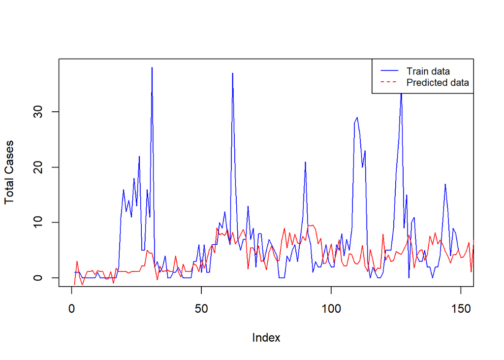

```r
plot(svr_iq)
plot(iq_test_reg$total_cases,type = 'l',ylab ="Total Cases",pch = 4, col = "blue")
lines(predict_svr,col ="red")
legend("topright", legend=c("Train data", "Predicted data"),
       col=c("blue", "red"), lty=1:2, cex=0.8)
```

```r
svr_mse = mean((iq_test_reg$total_cases - predict_svr)^2)
svr_mae = caret::MAE(iq_test_reg$total_cases, predict_svr)
svr_rmse = caret::RMSE(iq_test_reg$total_cases, predict_svr)
svr_SSE <- sum((iq_test_reg$total_cases - predict_svr)**2)
svr_SSR <- sum((predict_svr - mean(iq_test_reg$total_cases)) ** 2)
svr_R2 <- 1 - svr_SSE/(svr_SSE + svr_SSR)

cat("MSE: ", svr_mse, "MAE: ", svr_mae, " RMSE: ", svr_rmse, "R2", svr_R2)
```

```
## MSE:  69.9607 MAE:  5.652371  RMSE:  8.364251 R2 0.1354269
```

```r
vals <- matrix(c(mse, bm_mse, svr_mse, mae,bm_mae,svr_mae, rmse, bm_rmse,svr_rmse, R2, bm_R2, svr_R2),ncol=3,nrow = 4,byrow=TRUE)
colnames(vals) <- c("Linear regress  ","Backward Stepwise model", "SVR model")
rownames(vals) <- c("MSE","MAE","RMSE","R2")
as.table(vals)
```

```
##      Linear regress   Backward Stepwise model  SVR model
## MSE        56.9086100              57.6947649 69.9606965
## MAE         5.9849671               5.9785769  5.6523705
## RMSE        7.5437796               7.5957070  8.3642511
## R2          0.2070380               0.1896041  0.1354269
```

# SJ regression model

```r
# Do linear regression model using train data
sj_lm <- lm(total_cases~., data = sj_train_reg)
summary(sj_lm)
```

```
##
## Call:
## lm(formula = total_cases ~ ., data = sj_train_reg)
##
## Residuals:
##    Min     1Q Median     3Q    Max
## -84.64 -27.62 -10.56   7.36 365.78
##
## Coefficients:
##                                         Estimate Std. Error t value Pr(>|t|)
## (Intercept)                           8486.99751 9256.50967   0.917  0.35956
## ndvi_ne                                -48.85381   30.02903  -1.627  0.10425
## ndvi_nw                                 66.07021   32.97069   2.004  0.04550 *
## ndvi_se                                 99.42637   69.33457   1.434  0.15206
## ndvi_sw                                -50.20458   69.88138  -0.718  0.47276
## precipitation_amt_mm                     0.15731    1.14320   0.138  0.89060
## reanalysis_air_temp_k                   30.04456   79.41403   0.378  0.70531
## reanalysis_avg_temp_k                  -52.35047   29.33629  -1.784  0.07481 .
## reanalysis_dew_point_temp_k            -30.69326   73.04532  -0.420  0.67448
## reanalysis_max_air_temp_k               20.21824    7.05203   2.867  0.00428 **
## reanalysis_min_air_temp_k                2.02575    7.43978   0.272  0.78549
## reanalysis_precip_amt_kg_per_m2          0.04418    0.08213   0.538  0.59080
## reanalysis_relative_humidity_percent    -1.93792   16.16584  -0.120  0.90462
## reanalysis_sat_precip_amt_mm            -0.20223    1.14404  -0.177  0.85974
## reanalysis_specific_humidity_g_per_kg   37.43850   31.47234   1.190  0.23465
## reanalysis_tdtr_k                      -22.25647    7.61806  -2.922  0.00361 **
## station_avg_temp_c                      -3.49357    7.60731  -0.459  0.64622
## station_diur_temp_rng_c                  2.92755    4.61969   0.634  0.52649
## station_max_temp_c                       5.88398    3.79121   1.552  0.12115
## station_min_temp_c                       2.57276    4.55528   0.565  0.57242
## station_precip_mm                        0.01719    0.10317   0.167  0.86769
## ---
## Signif. codes:  0 '***' 0.001 '**' 0.01 '*' 0.05 '.' 0.1 ' ' 1
##
## Residual standard error: 56.2 on 644 degrees of freedom
## Multiple R-squared:  0.1069, Adjusted R-squared:  0.0792
## F-statistic: 3.856 on 20 and 644 DF,  p-value: 4.252e-08
```

```r
# Do prediction using linear regression model
sj_predict <- predict(sj_lm, newdata = sj_test_reg )
```

```r
mse1 = mean((sj_test_reg$total_cases - sj_predict)^2)
mae1 = caret::MAE(sj_test_reg$total_cases, sj_predict)
rmse1 = caret::RMSE(sj_test_reg$total_cases, sj_predict)
SSE1 <- sum((sj_test_reg$total_cases - sj_predict)**2)
SSR1 <- sum((sj_predict - mean(sj_test_reg$total_cases)) ** 2)
R2_1 <- 1 - SSE1/(SSE1 + SSR1)

cat("MSE: ", mse1, "MAE: ", mae1, " RMSE: ", rmse1, "R2", R2_1)
```

```
## MSE:  922.2455 MAE:  24.89286  RMSE:  30.3685 R2 0.3675561
```

```r
# Do backward stepwise model
backward_sj <- step (sj_lm, direction = 'backward')
```

```
## Start:  AIC=5379.11
## total_cases ~ ndvi_ne + ndvi_nw + ndvi_se + ndvi_sw + precipitation_amt_mm +
##     reanalysis_air_temp_k + reanalysis_avg_temp_k + reanalysis_dew_point_temp_k +
##     reanalysis_max_air_temp_k + reanalysis_min_air_temp_k + reanalysis_precip_amt_kg_per_m2 +
##     reanalysis_relative_humidity_percent + reanalysis_sat_precip_amt_mm +
##     reanalysis_specific_humidity_g_per_kg + reanalysis_tdtr_k +
##     station_avg_temp_c + station_diur_temp_rng_c + station_max_temp_c +
##     station_min_temp_c + station_precip_mm
##
##                                         Df Sum of Sq     RSS    AIC
## - reanalysis_relative_humidity_percent   1      45.4 2034044 5377.1
## - precipitation_amt_mm                   1      59.8 2034058 5377.1
## - station_precip_mm                      1      87.7 2034086 5377.1
## - reanalysis_sat_precip_amt_mm           1      98.7 2034097 5377.1
## - reanalysis_min_air_temp_k              1     234.2 2034233 5377.2
## - reanalysis_air_temp_k                  1     452.1 2034450 5377.3
## - reanalysis_dew_point_temp_k            1     557.7 2034556 5377.3
## - station_avg_temp_c                     1     666.1 2034664 5377.3
## - reanalysis_precip_amt_kg_per_m2        1     914.0 2034912 5377.4
## - station_min_temp_c                     1    1007.5 2035006 5377.4
## - station_diur_temp_rng_c                1    1268.4 2035267 5377.5
## - ndvi_sw                                1    1630.2 2035629 5377.6
## - reanalysis_specific_humidity_g_per_kg  1    4469.3 2038468 5378.6
## <none>                                               2033998 5379.1
## - ndvi_se                                1    6494.8 2040493 5379.2
## - station_max_temp_c                     1    7607.7 2041606 5379.6
## - ndvi_ne                                1    8359.5 2042358 5379.8
## - reanalysis_avg_temp_k                  1   10057.6 2044056 5380.4
## - ndvi_nw                                1   12682.9 2046681 5381.2
## - reanalysis_max_air_temp_k              1   25961.1 2059959 5385.5
## - reanalysis_tdtr_k                      1   26958.0 2060956 5385.9
##
## Step:  AIC=5377.12
## total_cases ~ ndvi_ne + ndvi_nw + ndvi_se + ndvi_sw + precipitation_amt_mm +
##     reanalysis_air_temp_k + reanalysis_avg_temp_k + reanalysis_dew_point_temp_k +
##     reanalysis_max_air_temp_k + reanalysis_min_air_temp_k + reanalysis_precip_amt_kg_per_m2 +
##     reanalysis_sat_precip_amt_mm + reanalysis_specific_humidity_g_per_kg +
##     reanalysis_tdtr_k + station_avg_temp_c + station_diur_temp_rng_c +
##     station_max_temp_c + station_min_temp_c + station_precip_mm
##
```

[output cut: 255 more lines]

```
## Step:  AIC=5358.87
## total_cases ~ ndvi_ne + ndvi_nw + ndvi_se + reanalysis_air_temp_k +
##     reanalysis_avg_temp_k + reanalysis_max_air_temp_k + reanalysis_tdtr_k +
##     station_max_temp_c
##
##                             Df Sum of Sq     RSS    AIC
## <none>                                   2045551 5358.9
## - ndvi_ne                    1      7263 2052814 5359.2
## - ndvi_se                    1      7875 2053426 5359.4
## - reanalysis_air_temp_k      1      8638 2054189 5359.7
## - ndvi_nw                    1     12771 2058323 5361.0
## - reanalysis_avg_temp_k      1     15119 2060670 5361.8
## - station_max_temp_c         1     22618 2068169 5364.2
## - reanalysis_max_air_temp_k  1     31748 2077299 5367.1
## - reanalysis_tdtr_k          1     42217 2087768 5370.5
```

```r
# Prediction using backward stepwise model
predict_sjbsm <- predict(backward_sj, newdata = sj_test_reg)
```

```r
bm_mse1 = mean((sj_test_reg$total_cases - predict_sjbsm)^2)
bm_mae1 = caret::MAE(sj_test_reg$total_cases, predict_sjbsm)
bm_rmse1 = caret::RMSE(sj_test_reg$total_cases, predict_sjbsm)
bm_SSE1 <- sum((sj_test_reg$total_cases - predict_sjbsm)**2)
bm_SSR1 <- sum((predict_sjbsm - mean(sj_test_reg$total_cases)) ** 2)
bm_R2_1 <- 1 - bm_SSE1/(bm_SSE1 + bm_SSR1)

cat("MSE: ", bm_mse1, "MAE: ", bm_mae1, " RMSE: ", bm_rmse1, "R2", bm_R2_1)
```

```
## MSE:  946.3295 MAE:  25.30556  RMSE:  30.76247 R2 0.3563274
```

```r
# svr model
svr_sj <-svm(formula  = total_cases ~., data = sj_train_reg, type = "eps-regression")
summary(svr_sj)
```

```
##
## Call:
## svm(formula = total_cases ~ ., data = sj_train_reg, type = "eps-regression")
##
##
## Parameters:
##    SVM-Type:  eps-regression
##  SVM-Kernel:  radial
##        cost:  1
##       gamma:  0.05
##     epsilon:  0.1
##
##
## Number of Support Vectors:  493
```

```r
# predicting using svr model
predict_sjsvr = predict(svr_sj, data = sj_test_reg)
```

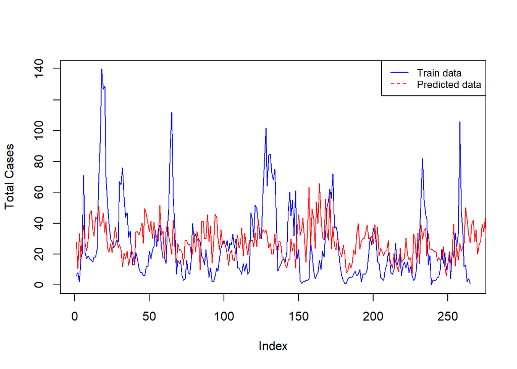

```r
plot(svr_sj)
plot(sj_test_reg$total_cases,type = 'l',ylab ="Total Cases",pch = 4, col = "blue")
lines(predict_sjsvr,col ="red")
legend("topright", legend=c("Train data", "Predicted data"),
       col=c("blue", "red"), lty=1:2, cex=0.8)
```

```r
svr_mse1 = mean((sj_test_reg$total_cases - predict_sjsvr)^2)
svr_mae1 = caret::MAE(sj_test_reg$total_cases, predict_sjsvr)
svr_rmse1 = caret::RMSE(sj_test_reg$total_cases, predict_sjsvr)
svr_SSE1 <- sum((sj_test_reg$total_cases - predict_sjsvr)**2)
svr_SSR1 <- sum((predict_sjsvr - mean(iq_test_reg$total_cases)) ** 2)
svr_R2_1 <- 1 - svr_SSE1/(svr_SSE1 + svr_SSR)
options(scipen = 0)

cat("MSE: ", svr_mse1, "MAE: ", svr_mae1, " RMSE: ", svr_rmse1, "R2", svr_R2_1)
```

```
## MSE:  800.1835 MAE:  20.2204  RMSE:  28.28752 R2 0.007460819
```

```r
vals1 <- matrix(c(mse1, bm_mse1, svr_mse1, mae1,bm_mae1,svr_mae1, rmse1, bm_rmse1,svr_rmse1, R2_1, bm_R2_1, svr_R2_1),ncol=3,nrow = 4,byrow=TRUE)
options (scipen = 0)
colnames(vals1) <- c("Linear regress  ","Backward Stepwise model", "SVR model")
rownames(vals1) <- c("MSE_sj","MAE_sj","RMSE_sj","R2_sj")
as.table(vals1)
```

```
##         Linear regress   Backward Stepwise model    SVR model
## MSE_sj      9.222455e+02            9.463295e+02 8.001835e+02
## MAE_sj      2.489286e+01            2.530556e+01 2.022040e+01
## RMSE_sj     3.036850e+01            3.076247e+01 2.828752e+01
## R2_sj       3.675561e-01            3.563274e-01 7.460819e-03
```

## Model Prediction (By Chiow Hui Qin)

In this part of the report, the prediction result of Classification Model and Regression Model will be evaluate. Test_cleaned.csv file that being created during data pre-processing step will be used in both model.

### Import the test data

```r
df_predict <-  read.csv("https://raw.githubusercontent.com/KewJS/wqd7004-dengai/main/data/Test_cleaned.csv")

#### Read data (Cleaned test data)

head(df_predict,5)%>%
  kable() %>%
  kable_styling()
```

| city | year | weekofyear | week_start_date | ndvi_ne | ndvi_nw | ndvi_se | ndvi_sw | precipitation_amt_mm | reanalysis_air_temp_k | reanalysis_avg_temp_k | reanalysis_dew_point_temp_k | reanalysis_max_air_temp_k | reanalysis_min_air_temp_k | reanalysis_precip_amt_kg_per_m2 | reanalysis_relative_humidity_percent | reanalysis_sat_precip_amt_mm | reanalysis_specific_humidity_g_per_kg | reanalysis_tdtr_k | station_avg_temp_c | station_diur_temp_rng_c | station_max_temp_c | station_min_temp_c | station_precip_mm |
| --- | --- | --- | --- | --- | --- | --- | --- | --- | --- | --- | --- | --- | --- | --- | --- | --- | --- | --- | --- | --- | --- | --- | --- |
| iq | 2010 | 26 | 2010-07-02 | 0.1837833 | 0.1425000 | 0.2251286 | 0.1502143 | 82.29 | 297.6486 | 299.2143 | 296.1186 | 307.9 | 293.7 | 34.11 | 92.58143 | 82.29 | 17.65429 | 9.428571 | 27.440 | 10.760 | 33.8 | 21.5 | 11.2 |
| iq | 2010 | 27 | 2010-07-09 | 0.2916571 | 0.2722667 | 0.3307000 | 0.3209143 | 25.30 | 298.2243 | 299.4643 | 294.8314 | 307.7 | 292.2 | 9.10 | 83.88571 | 25.30 | 16.32000 | 10.157143 | 27.025 | 9.625 | 33.0 | 21.2 | 8.9 |
| iq | 2010 | 28 | 2010-07-16 | 0.2085429 | 0.3664571 | 0.2126286 | 0.2555143 | 62.14 | 297.9557 | 298.9643 | 296.4171 | 306.4 | 292.5 | 61.09 | 92.05714 | 62.14 | 18.03000 | 9.557143 | 26.950 | 10.350 | 33.4 | 21.6 | 22.6 |
| iq | 2010 | 29 | 2010-07-23 | 0.0892857 | 0.0632143 | 0.1220571 | 0.0819571 | 47.80 | 295.7157 | 296.6429 | 293.6386 | 306.4 | 289.3 | 19.60 | 88.97000 | 47.80 | 15.39429 | 7.828571 | 26.900 | 9.700 | 33.3 | 14.2 | 4.8 |
| iq | 2010 | 30 | 2010-07-30 | 0.3061000 | 0.3276833 | 0.2500857 | 0.2679143 | 56.30 | 298.5029 | 300.0000 | 293.8929 | 308.1 | 290.5 | 18.93 | 78.61000 | 56.30 | 15.46857 | 11.771429 | 27.050 | 11.850 | 33.5 | 16.9 | 3.0 |

classification model chosen (SVM algorithm is used) : iq_model for Iquitos and sj_model for San Juan Regression model chosen (Linear regression algorithm is used) : iq_lm for Iquitos and sj_lm for San Juan

### Prepare the prediction data according to city

Split the data according to the city

```r
iq_df<- df_predict[which(df_predict$city=="iq"),]
sj_df<- df_predict[which(df_predict$city=="sj"),]
```

Checking the dataset of Iquitos city

```r
head(iq_df,5) %>%
  kable() %>%
  kable_styling()
```

| city | year | weekofyear | week_start_date | ndvi_ne | ndvi_nw | ndvi_se | ndvi_sw | precipitation_amt_mm | reanalysis_air_temp_k | reanalysis_avg_temp_k | reanalysis_dew_point_temp_k | reanalysis_max_air_temp_k | reanalysis_min_air_temp_k | reanalysis_precip_amt_kg_per_m2 | reanalysis_relative_humidity_percent | reanalysis_sat_precip_amt_mm | reanalysis_specific_humidity_g_per_kg | reanalysis_tdtr_k | station_avg_temp_c | station_diur_temp_rng_c | station_max_temp_c | station_min_temp_c | station_precip_mm |
| --- | --- | --- | --- | --- | --- | --- | --- | --- | --- | --- | --- | --- | --- | --- | --- | --- | --- | --- | --- | --- | --- | --- | --- |
| iq | 2010 | 26 | 2010-07-02 | 0.1837833 | 0.1425000 | 0.2251286 | 0.1502143 | 82.29 | 297.6486 | 299.2143 | 296.1186 | 307.9 | 293.7 | 34.11 | 92.58143 | 82.29 | 17.65429 | 9.428571 | 27.440 | 10.760 | 33.8 | 21.5 | 11.2 |
| iq | 2010 | 27 | 2010-07-09 | 0.2916571 | 0.2722667 | 0.3307000 | 0.3209143 | 25.30 | 298.2243 | 299.4643 | 294.8314 | 307.7 | 292.2 | 9.10 | 83.88571 | 25.30 | 16.32000 | 10.157143 | 27.025 | 9.625 | 33.0 | 21.2 | 8.9 |
| iq | 2010 | 28 | 2010-07-16 | 0.2085429 | 0.3664571 | 0.2126286 | 0.2555143 | 62.14 | 297.9557 | 298.9643 | 296.4171 | 306.4 | 292.5 | 61.09 | 92.05714 | 62.14 | 18.03000 | 9.557143 | 26.950 | 10.350 | 33.4 | 21.6 | 22.6 |
| iq | 2010 | 29 | 2010-07-23 | 0.0892857 | 0.0632143 | 0.1220571 | 0.0819571 | 47.80 | 295.7157 | 296.6429 | 293.6386 | 306.4 | 289.3 | 19.60 | 88.97000 | 47.80 | 15.39429 | 7.828571 | 26.900 | 9.700 | 33.3 | 14.2 | 4.8 |
| iq | 2010 | 30 | 2010-07-30 | 0.3061000 | 0.3276833 | 0.2500857 | 0.2679143 | 56.30 | 298.5029 | 300.0000 | 293.8929 | 308.1 | 290.5 | 18.93 | 78.61000 | 56.30 | 15.46857 | 11.771429 | 27.050 | 11.850 | 33.5 | 16.9 | 3.0 |

Checking the dataset of San Juan city

```r
head(sj_df,5) %>%
  kable() %>%
  kable_styling()
```

|  | city | year | weekofyear | week_start_date | ndvi_ne | ndvi_nw | ndvi_se | ndvi_sw | precipitation_amt_mm | reanalysis_air_temp_k | reanalysis_avg_temp_k | reanalysis_dew_point_temp_k | reanalysis_max_air_temp_k | reanalysis_min_air_temp_k | reanalysis_precip_amt_kg_per_m2 | reanalysis_relative_humidity_percent | reanalysis_sat_precip_amt_mm | reanalysis_specific_humidity_g_per_kg | reanalysis_tdtr_k | station_avg_temp_c | station_diur_temp_rng_c | station_max_temp_c | station_min_temp_c | station_precip_mm |
| --- | --- | --- | --- | --- | --- | --- | --- | --- | --- | --- | --- | --- | --- | --- | --- | --- | --- | --- | --- | --- | --- | --- | --- | --- |
| 157 | sj | 2008 | 18 | 2008-04-29 | -0.0189 | -0.0189000 | 0.1027286 | 0.0912000 | 78.60 | 298.4929 | 298.5500 | 294.5271 | 301.1 | 296.4 | 25.37 | 78.78143 | 78.60 | 15.91857 | 3.128571 | 26.52857 | 7.057143 | 33.3 | 21.7 | 75.2 |
| 158 | sj | 2008 | 19 | 2008-05-06 | -0.0180 | -0.0124000 | 0.0820429 | 0.0723143 | 12.56 | 298.4757 | 298.5571 | 294.3957 | 300.8 | 296.7 | 21.83 | 78.23000 | 12.56 | 15.79143 | 2.571429 | 26.07143 | 5.557143 | 30.0 | 22.2 | 34.3 |
| 159 | sj | 2008 | 20 | 2008-05-13 | -0.0015 | 0.0016800 | 0.1510833 | 0.0915286 | 3.66 | 299.4557 | 299.3571 | 295.3086 | 302.2 | 296.4 | 4.12 | 78.27000 | 3.66 | 16.67429 | 4.428571 | 27.92857 | 7.785714 | 32.8 | 22.8 | 3.0 |
| 160 | sj | 2008 | 21 | 2008-05-20 | 0.0108 | -0.0198667 | 0.1243286 | 0.1256857 | 0.00 | 299.6900 | 299.7286 | 294.4029 | 303.0 | 296.9 | 2.20 | 73.01571 | 0.00 | 15.77571 | 4.342857 | 28.05714 | 6.271429 | 33.3 | 24.4 | 0.3 |
| 161 | sj | 2008 | 22 | 2008-05-27 | 0.0568 | 0.0398333 | 0.0622667 | 0.0759143 | 0.76 | 299.7800 | 299.6714 | 294.7600 | 302.3 | 297.3 | 4.36 | 74.08429 | 0.76 | 16.13714 | 3.542857 | 27.61429 | 7.085714 | 33.3 | 23.3 | 84.1 |

### Prediction in Iquitos city

#### Information about the result of the model

Classification model will predict whether an outbreak is happened, the outcome of the prediction will be Yes or No. Regression model will predict the total cases that was going to happen.

Below show the test data being used in the prediction of classification model.

```r
iq_df$total_cases <- sample(100, size = nrow(iq_df), replace = TRUE)
iq_predict_classification <- predict(iq_Model, iq_df)

head(iq_df[,-1],5)%>%
  kable() %>%
  kable_styling()
```

| year | weekofyear | week_start_date | ndvi_ne | ndvi_nw | ndvi_se | ndvi_sw | precipitation_amt_mm | reanalysis_air_temp_k | reanalysis_avg_temp_k | reanalysis_dew_point_temp_k | reanalysis_max_air_temp_k | reanalysis_min_air_temp_k | reanalysis_precip_amt_kg_per_m2 | reanalysis_relative_humidity_percent | reanalysis_sat_precip_amt_mm | reanalysis_specific_humidity_g_per_kg | reanalysis_tdtr_k | station_avg_temp_c | station_diur_temp_rng_c | station_max_temp_c | station_min_temp_c | station_precip_mm | total_cases |
| --- | --- | --- | --- | --- | --- | --- | --- | --- | --- | --- | --- | --- | --- | --- | --- | --- | --- | --- | --- | --- | --- | --- | --- |
| 2010 | 26 | 2010-07-02 | 0.1837833 | 0.1425000 | 0.2251286 | 0.1502143 | 82.29 | 297.6486 | 299.2143 | 296.1186 | 307.9 | 293.7 | 34.11 | 92.58143 | 82.29 | 17.65429 | 9.428571 | 27.440 | 10.760 | 33.8 | 21.5 | 11.2 | 92 |
| 2010 | 27 | 2010-07-09 | 0.2916571 | 0.2722667 | 0.3307000 | 0.3209143 | 25.30 | 298.2243 | 299.4643 | 294.8314 | 307.7 | 292.2 | 9.10 | 83.88571 | 25.30 | 16.32000 | 10.157143 | 27.025 | 9.625 | 33.0 | 21.2 | 8.9 | 61 |
| 2010 | 28 | 2010-07-16 | 0.2085429 | 0.3664571 | 0.2126286 | 0.2555143 | 62.14 | 297.9557 | 298.9643 | 296.4171 | 306.4 | 292.5 | 61.09 | 92.05714 | 62.14 | 18.03000 | 9.557143 | 26.950 | 10.350 | 33.4 | 21.6 | 22.6 | 60 |
| 2010 | 29 | 2010-07-23 | 0.0892857 | 0.0632143 | 0.1220571 | 0.0819571 | 47.80 | 295.7157 | 296.6429 | 293.6386 | 306.4 | 289.3 | 19.60 | 88.97000 | 47.80 | 15.39429 | 7.828571 | 26.900 | 9.700 | 33.3 | 14.2 | 4.8 | 27 |
| 2010 | 30 | 2010-07-30 | 0.3061000 | 0.3276833 | 0.2500857 | 0.2679143 | 56.30 | 298.5029 | 300.0000 | 293.8929 | 308.1 | 290.5 | 18.93 | 78.61000 | 56.30 | 15.46857 | 11.771429 | 27.050 | 11.850 | 33.5 | 16.9 | 3.0 | 98 |

The Prediction of outbreak for Iquitos city using Classification Model

```r
head(iq_predict_classification,5) %>%
  kable() %>%
  kable_styling()
```

| x |
| --- |
| Yes |
| Yes |
| Yes |
| Yes |
| Yes |

```r
classification_result =iq_df
classification_result$prediction_ret<- iq_predict_classification
```

```r
head(classification_result,5)%>%
  kable() %>%
  kable_styling()
```

| city | year | weekofyear | week_start_date | ndvi_ne | ndvi_nw | ndvi_se | ndvi_sw | precipitation_amt_mm | reanalysis_air_temp_k | reanalysis_avg_temp_k | reanalysis_dew_point_temp_k | reanalysis_max_air_temp_k | reanalysis_min_air_temp_k | reanalysis_precip_amt_kg_per_m2 | reanalysis_relative_humidity_percent | reanalysis_sat_precip_amt_mm | reanalysis_specific_humidity_g_per_kg | reanalysis_tdtr_k | station_avg_temp_c | station_diur_temp_rng_c | station_max_temp_c | station_min_temp_c | station_precip_mm | total_cases | prediction_ret |
| --- | --- | --- | --- | --- | --- | --- | --- | --- | --- | --- | --- | --- | --- | --- | --- | --- | --- | --- | --- | --- | --- | --- | --- | --- | --- |
| iq | 2010 | 26 | 2010-07-02 | 0.1837833 | 0.1425000 | 0.2251286 | 0.1502143 | 82.29 | 297.6486 | 299.2143 | 296.1186 | 307.9 | 293.7 | 34.11 | 92.58143 | 82.29 | 17.65429 | 9.428571 | 27.440 | 10.760 | 33.8 | 21.5 | 11.2 | 92 | Yes |
| iq | 2010 | 27 | 2010-07-09 | 0.2916571 | 0.2722667 | 0.3307000 | 0.3209143 | 25.30 | 298.2243 | 299.4643 | 294.8314 | 307.7 | 292.2 | 9.10 | 83.88571 | 25.30 | 16.32000 | 10.157143 | 27.025 | 9.625 | 33.0 | 21.2 | 8.9 | 61 | Yes |
| iq | 2010 | 28 | 2010-07-16 | 0.2085429 | 0.3664571 | 0.2126286 | 0.2555143 | 62.14 | 297.9557 | 298.9643 | 296.4171 | 306.4 | 292.5 | 61.09 | 92.05714 | 62.14 | 18.03000 | 9.557143 | 26.950 | 10.350 | 33.4 | 21.6 | 22.6 | 60 | Yes |
| iq | 2010 | 29 | 2010-07-23 | 0.0892857 | 0.0632143 | 0.1220571 | 0.0819571 | 47.80 | 295.7157 | 296.6429 | 293.6386 | 306.4 | 289.3 | 19.60 | 88.97000 | 47.80 | 15.39429 | 7.828571 | 26.900 | 9.700 | 33.3 | 14.2 | 4.8 | 27 | Yes |
| iq | 2010 | 30 | 2010-07-30 | 0.3061000 | 0.3276833 | 0.2500857 | 0.2679143 | 56.30 | 298.5029 | 300.0000 | 293.8929 | 308.1 | 290.5 | 18.93 | 78.61000 | 56.30 | 15.46857 | 11.771429 | 27.050 | 11.850 | 33.5 | 16.9 | 3.0 | 98 | Yes |

## Prediction Analysis for classification model

Seperate the data frame into outbreak happened and outbreak not happen

```r
outbreak_happen_df = classification_result[which(classification_result$prediction_ret=="Yes"),]
outbreak_not_happen_df= classification_result[which(classification_result$prediction_ret=="No"),]
head(outbreak_happen_df,5)%>%
  kable() %>%
  kable_styling()
```

| city | year | weekofyear | week_start_date | ndvi_ne | ndvi_nw | ndvi_se | ndvi_sw | precipitation_amt_mm | reanalysis_air_temp_k | reanalysis_avg_temp_k | reanalysis_dew_point_temp_k | reanalysis_max_air_temp_k | reanalysis_min_air_temp_k | reanalysis_precip_amt_kg_per_m2 | reanalysis_relative_humidity_percent | reanalysis_sat_precip_amt_mm | reanalysis_specific_humidity_g_per_kg | reanalysis_tdtr_k | station_avg_temp_c | station_diur_temp_rng_c | station_max_temp_c | station_min_temp_c | station_precip_mm | total_cases | prediction_ret |
| --- | --- | --- | --- | --- | --- | --- | --- | --- | --- | --- | --- | --- | --- | --- | --- | --- | --- | --- | --- | --- | --- | --- | --- | --- | --- |
| iq | 2010 | 26 | 2010-07-02 | 0.1837833 | 0.1425000 | 0.2251286 | 0.1502143 | 82.29 | 297.6486 | 299.2143 | 296.1186 | 307.9 | 293.7 | 34.11 | 92.58143 | 82.29 | 17.65429 | 9.428571 | 27.440 | 10.760 | 33.8 | 21.5 | 11.2 | 92 | Yes |
| iq | 2010 | 27 | 2010-07-09 | 0.2916571 | 0.2722667 | 0.3307000 | 0.3209143 | 25.30 | 298.2243 | 299.4643 | 294.8314 | 307.7 | 292.2 | 9.10 | 83.88571 | 25.30 | 16.32000 | 10.157143 | 27.025 | 9.625 | 33.0 | 21.2 | 8.9 | 61 | Yes |
| iq | 2010 | 28 | 2010-07-16 | 0.2085429 | 0.3664571 | 0.2126286 | 0.2555143 | 62.14 | 297.9557 | 298.9643 | 296.4171 | 306.4 | 292.5 | 61.09 | 92.05714 | 62.14 | 18.03000 | 9.557143 | 26.950 | 10.350 | 33.4 | 21.6 | 22.6 | 60 | Yes |
| iq | 2010 | 29 | 2010-07-23 | 0.0892857 | 0.0632143 | 0.1220571 | 0.0819571 | 47.80 | 295.7157 | 296.6429 | 293.6386 | 306.4 | 289.3 | 19.60 | 88.97000 | 47.80 | 15.39429 | 7.828571 | 26.900 | 9.700 | 33.3 | 14.2 | 4.8 | 27 | Yes |
| iq | 2010 | 30 | 2010-07-30 | 0.3061000 | 0.3276833 | 0.2500857 | 0.2679143 | 56.30 | 298.5029 | 300.0000 | 293.8929 | 308.1 | 290.5 | 18.93 | 78.61000 | 56.30 | 15.46857 | 11.771429 | 27.050 | 11.850 | 33.5 | 16.9 | 3.0 | 98 | Yes |

```r
head(outbreak_not_happen_df,5)%>%
  kable() %>%
  kable_styling()
```

|  | city | year | weekofyear | week_start_date | ndvi_ne | ndvi_nw | ndvi_se | ndvi_sw | precipitation_amt_mm | reanalysis_air_temp_k | reanalysis_avg_temp_k | reanalysis_dew_point_temp_k | reanalysis_max_air_temp_k | reanalysis_min_air_temp_k | reanalysis_precip_amt_kg_per_m2 | reanalysis_relative_humidity_percent | reanalysis_sat_precip_amt_mm | reanalysis_specific_humidity_g_per_kg | reanalysis_tdtr_k | station_avg_temp_c | station_diur_temp_rng_c | station_max_temp_c | station_min_temp_c | station_precip_mm | total_cases | prediction_ret |
| --- | --- | --- | --- | --- | --- | --- | --- | --- | --- | --- | --- | --- | --- | --- | --- | --- | --- | --- | --- | --- | --- | --- | --- | --- | --- | --- |
| 28 | iq | 2011 | 1 | 2011-01-08 | 0.3677429 | 0.3201429 | 0.3127714 | 0.3882571 | 10.08 | 298.8757 | 300.2429 | 294.6986 | 306.9 | 293.2 | 44.87 | 80.45286 | 10.08 | 16.40286 | 10.514286 | 27.85 | 12.35000 | 36.0 | 21.2 | 0.0 | 1 | No |
| 44 | iq | 2011 | 17 | 2011-04-30 | 0.2891000 | 0.3540600 | 0.1965571 | 0.2656857 | 89.33 | 297.2771 | 298.6143 | 296.7700 | 305.2 | 292.8 | 97.20 | 97.30143 | 89.33 | 18.44714 | 7.657143 | 28.10 | 10.20000 | 33.2 | 22.3 | 24.0 | 3 | No |
| 48 | iq | 2011 | 21 | 2011-05-28 | 0.2827571 | 0.2121714 | 0.2726429 | 0.3207000 | 105.13 | 297.5400 | 298.9429 | 295.9314 | 307.6 | 292.2 | 35.90 | 92.12857 | 105.13 | 17.54571 | 9.542857 | 27.44 | 10.03333 | 33.2 | 21.4 | 38.1 | 8 | No |
| 63 | iq | 2011 | 36 | 2011-09-10 | 0.2720000 | 0.2638000 | 0.2696143 | 0.2356143 | 23.04 | 297.7200 | 299.3286 | 293.7157 | 309.8 | 291.8 | 11.40 | 80.79000 | 23.04 | 15.27143 | 12.657143 | 27.80 | 12.23333 | 34.8 | 21.6 | 12.9 | 1 | No |
| 84 | iq | 2012 | 5 | 2012-02-05 | 0.1099500 | 0.1662714 | 0.2246429 | 0.2218857 | 56.99 | 297.4357 | 298.6571 | 296.4386 | 305.3 | 292.3 | 65.70 | 95.01286 | 56.99 | 18.10571 | 7.828571 | 27.15 | 9.55000 | 32.6 | 22.0 | 23.0 | 5 | No |

### Relationship between total case and prediction result

#### Classification Analysis of Outbreak going to happen in Iquitos City

```r
outbreak_happen_df<-outbreak_happen_df%>%
                     select_if(is.numeric)
head(outbreak_happen_df,5)
```

```
##   year weekofyear    ndvi_ne    ndvi_nw   ndvi_se    ndvi_sw
## 1 2010         26 0.18378330 0.14250000 0.2251286 0.15021430
## 2 2010         27 0.29165710 0.27226670 0.3307000 0.32091430
## 3 2010         28 0.20854290 0.36645710 0.2126286 0.25551430
## 4 2010         29 0.08928571 0.06321429 0.1220571 0.08195714
## 5 2010         30 0.30610000 0.32768330 0.2500857 0.26791430
##   precipitation_amt_mm reanalysis_air_temp_k reanalysis_avg_temp_k
## 1                82.29              297.6486              299.2143
## 2                25.30              298.2243              299.4643
## 3                62.14              297.9557              298.9643
## 4                47.80              295.7157              296.6429
## 5                56.30              298.5029              300.0000
##   reanalysis_dew_point_temp_k reanalysis_max_air_temp_k
## 1                    296.1186                     307.9
## 2                    294.8314                     307.7
```

[output cut: 33 more lines]

```r
sapply(outbreak_happen_df,min)%>%
  kable() %>%
  kable_styling()
```

|  | x |
| --- | --- |
| year | 2010.0000000 |
| weekofyear | 1.0000000 |
| ndvi_ne | 0.0892857 |
| ndvi_nw | 0.0632143 |
| ndvi_se | 0.0982571 |
| ndvi_sw | 0.0819571 |
| precipitation_amt_mm | 2.2800000 |
| reanalysis_air_temp_k | 294.5542857 |
| reanalysis_avg_temp_k | 295.2357143 |
| reanalysis_dew_point_temp_k | 291.9542857 |
| reanalysis_max_air_temp_k | 302.8000000 |
| reanalysis_min_air_temp_k | 286.2000000 |
| reanalysis_precip_amt_kg_per_m2 | 2.6000000 |
| reanalysis_relative_humidity_percent | 66.3100000 |
| reanalysis_sat_precip_amt_mm | 2.2800000 |
| reanalysis_specific_humidity_g_per_kg | 13.7371429 |
| reanalysis_tdtr_k | 4.8000000 |
| station_avg_temp_c | 24.8400000 |
| station_diur_temp_rng_c | 6.4500000 |
| station_max_temp_c | 29.6000000 |
| station_min_temp_c | 14.2000000 |
| station_precip_mm | 0.0000000 |
| total_cases | 4.0000000 |

```r
sapply(outbreak_happen_df,max)%>%
  kable() %>%
  kable_styling()
```

|  | x |
| --- | --- |
| year | 2013.0000000 |
| weekofyear | 52.0000000 |
| ndvi_ne | 0.4299857 |
| ndvi_nw | 0.4648000 |
| ndvi_se | 0.4530429 |
| ndvi_sw | 0.5290429 |
| precipitation_amt_mm | 152.3200000 |
| reanalysis_air_temp_k | 301.9357143 |
| reanalysis_avg_temp_k | 303.3285714 |
| reanalysis_dew_point_temp_k | 297.7257143 |
| reanalysis_max_air_temp_k | 314.1000000 |
| reanalysis_min_air_temp_k | 296.0000000 |
| reanalysis_precip_amt_kg_per_m2 | 280.4200000 |
| reanalysis_relative_humidity_percent | 97.9828571 |
| reanalysis_sat_precip_amt_mm | 152.3200000 |
| reanalysis_specific_humidity_g_per_kg | 19.5985714 |
| reanalysis_tdtr_k | 14.4857143 |
| station_avg_temp_c | 29.1333333 |
| station_diur_temp_rng_c | 14.7250000 |
| station_max_temp_c | 38.4000000 |
| station_min_temp_c | 23.2000000 |
| station_precip_mm | 212.0000000 |
| total_cases | 100.0000000 |

#### Classification analysis of outbreak not happen in Iquitos City

```r
outbreak_not_happen_df<-outbreak_not_happen_df%>%
                     select_if(is.numeric)
head(outbreak_not_happen_df,5)
```

```
##    year weekofyear   ndvi_ne   ndvi_nw   ndvi_se   ndvi_sw precipitation_amt_mm
## 28 2011          1 0.3677429 0.3201429 0.3127714 0.3882571                10.08
## 44 2011         17 0.2891000 0.3540600 0.1965571 0.2656857                89.33
## 48 2011         21 0.2827571 0.2121714 0.2726429 0.3207000               105.13
## 63 2011         36 0.2720000 0.2638000 0.2696143 0.2356143                23.04
## 84 2012          5 0.1099500 0.1662714 0.2246429 0.2218857                56.99
##    reanalysis_air_temp_k reanalysis_avg_temp_k reanalysis_dew_point_temp_k
## 28              298.8757              300.2429                    294.6986
## 44              297.2771              298.6143                    296.7700
## 48              297.5400              298.9429                    295.9314
## 63              297.7200              299.3286                    293.7157
## 84              297.4357              298.6571                    296.4386
##    reanalysis_max_air_temp_k reanalysis_min_air_temp_k
## 28                     306.9                     293.2
## 44                     305.2                     292.8
```

[output cut: 27 more lines]

```r
sapply(outbreak_not_happen_df,min)%>%
  kable() %>%
  kable_styling()
```

|  | x |
| --- | --- |
| year | 2011.0000000 |
| weekofyear | 1.0000000 |
| ndvi_ne | 0.1099500 |
| ndvi_nw | 0.1662714 |
| ndvi_se | 0.1430571 |
| ndvi_sw | 0.2021000 |
| precipitation_amt_mm | 10.0800000 |
| reanalysis_air_temp_k | 296.5142857 |
| reanalysis_avg_temp_k | 297.6000000 |
| reanalysis_dew_point_temp_k | 293.7157143 |
| reanalysis_max_air_temp_k | 303.5000000 |
| reanalysis_min_air_temp_k | 290.6000000 |
| reanalysis_precip_amt_kg_per_m2 | 11.4000000 |
| reanalysis_relative_humidity_percent | 80.4528571 |
| reanalysis_sat_precip_amt_mm | 10.0800000 |
| reanalysis_specific_humidity_g_per_kg | 15.2714286 |
| reanalysis_tdtr_k | 5.3714286 |
| station_avg_temp_c | 26.0000000 |
| station_diur_temp_rng_c | 8.9750000 |
| station_max_temp_c | 32.0000000 |
| station_min_temp_c | 19.8000000 |
| station_precip_mm | 0.0000000 |
| total_cases | 1.0000000 |

```r
sapply(outbreak_not_happen_df,max)%>%
  kable() %>%
  kable_styling()
```

|  | x |
| --- | --- |
| year | 2013.0000000 |
| weekofyear | 36.0000000 |
| ndvi_ne | 0.3677429 |
| ndvi_nw | 0.3800286 |
| ndvi_se | 0.3127714 |
| ndvi_sw | 0.3882571 |
| precipitation_amt_mm | 149.8800000 |
| reanalysis_air_temp_k | 298.8757143 |
| reanalysis_avg_temp_k | 300.2428571 |
| reanalysis_dew_point_temp_k | 296.7700000 |
| reanalysis_max_air_temp_k | 309.8000000 |
| reanalysis_min_air_temp_k | 294.9000000 |
| reanalysis_precip_amt_kg_per_m2 | 245.1000000 |
| reanalysis_relative_humidity_percent | 97.3014286 |
| reanalysis_sat_precip_amt_mm | 149.8800000 |
| reanalysis_specific_humidity_g_per_kg | 18.4471429 |
| reanalysis_tdtr_k | 12.6571429 |
| station_avg_temp_c | 28.1000000 |
| station_diur_temp_rng_c | 12.3500000 |
| station_max_temp_c | 36.0000000 |
| station_min_temp_c | 22.3000000 |
| station_precip_mm | 138.1000000 |
| total_cases | 8.0000000 |

#### Regression model to predict the total case that will happen in Iquitos City

```r
#Regression Model

iq_predict_regression <-predict(iq_lm, iq_df,interval = 'confidence')

head(iq_predict_regression,10)  %>%
  kable() %>%
  kable_styling()
```

| fit | lwr | upr |
| --- | --- | --- |
| 6.6038219 | 2.5466528 | 10.660991 |
| 5.3170266 | 1.4095473 | 9.224506 |
| 8.1757455 | 2.1541877 | 14.197303 |
| -1.7875207 | -14.0860779 | 10.511037 |
| -0.3357545 | -7.6437549 | 6.972246 |
| 5.0863791 | 0.8123371 | 9.360421 |
| 3.9999609 | -3.3992069 | 11.399129 |
| 6.1139312 | 1.6301243 | 10.597738 |
| 5.6794956 | -0.6113707 | 11.970362 |
| 8.7277259 | 4.6437486 | 12.811703 |

### Prediction in San Juan City

```r
#Classification Model
sj_df$total_cases <- sample(100, size = nrow(sj_df), replace = TRUE)

head(sj_df[,-1],5)%>%
  kable() %>%
  kable_styling()
```

|  | year | weekofyear | week_start_date | ndvi_ne | ndvi_nw | ndvi_se | ndvi_sw | precipitation_amt_mm | reanalysis_air_temp_k | reanalysis_avg_temp_k | reanalysis_dew_point_temp_k | reanalysis_max_air_temp_k | reanalysis_min_air_temp_k | reanalysis_precip_amt_kg_per_m2 | reanalysis_relative_humidity_percent | reanalysis_sat_precip_amt_mm | reanalysis_specific_humidity_g_per_kg | reanalysis_tdtr_k | station_avg_temp_c | station_diur_temp_rng_c | station_max_temp_c | station_min_temp_c | station_precip_mm | total_cases |
| --- | --- | --- | --- | --- | --- | --- | --- | --- | --- | --- | --- | --- | --- | --- | --- | --- | --- | --- | --- | --- | --- | --- | --- | --- |
| 157 | 2008 | 18 | 2008-04-29 | -0.0189 | -0.0189000 | 0.1027286 | 0.0912000 | 78.60 | 298.4929 | 298.5500 | 294.5271 | 301.1 | 296.4 | 25.37 | 78.78143 | 78.60 | 15.91857 | 3.128571 | 26.52857 | 7.057143 | 33.3 | 21.7 | 75.2 | 70 |
| 158 | 2008 | 19 | 2008-05-06 | -0.0180 | -0.0124000 | 0.0820429 | 0.0723143 | 12.56 | 298.4757 | 298.5571 | 294.3957 | 300.8 | 296.7 | 21.83 | 78.23000 | 12.56 | 15.79143 | 2.571429 | 26.07143 | 5.557143 | 30.0 | 22.2 | 34.3 | 61 |
| 159 | 2008 | 20 | 2008-05-13 | -0.0015 | 0.0016800 | 0.1510833 | 0.0915286 | 3.66 | 299.4557 | 299.3571 | 295.3086 | 302.2 | 296.4 | 4.12 | 78.27000 | 3.66 | 16.67429 | 4.428571 | 27.92857 | 7.785714 | 32.8 | 22.8 | 3.0 | 77 |
| 160 | 2008 | 21 | 2008-05-20 | 0.0108 | -0.0198667 | 0.1243286 | 0.1256857 | 0.00 | 299.6900 | 299.7286 | 294.4029 | 303.0 | 296.9 | 2.20 | 73.01571 | 0.00 | 15.77571 | 4.342857 | 28.05714 | 6.271429 | 33.3 | 24.4 | 0.3 | 60 |
| 161 | 2008 | 22 | 2008-05-27 | 0.0568 | 0.0398333 | 0.0622667 | 0.0759143 | 0.76 | 299.7800 | 299.6714 | 294.7600 | 302.3 | 297.3 | 4.36 | 74.08429 | 0.76 | 16.13714 | 3.542857 | 27.61429 | 7.085714 | 33.3 | 23.3 | 84.1 | 28 |

```r
sj_predict_classification <- predict(sj_Model, sj_df)
```

```r
head(sj_predict_classification,5) %>%
  kable() %>%
  kable_styling()
```

| x |
| --- |
| No |
| No |
| Yes |
| Yes |
| Yes |

```r
classification_result_sj =sj_df
classification_result_sj$prediction_ret<- sj_predict_classification
```

```r
head(classification_result_sj,5)%>%
  kable() %>%
  kable_styling()
```

|  | city | year | weekofyear | week_start_date | ndvi_ne | ndvi_nw | ndvi_se | ndvi_sw | precipitation_amt_mm | reanalysis_air_temp_k | reanalysis_avg_temp_k | reanalysis_dew_point_temp_k | reanalysis_max_air_temp_k | reanalysis_min_air_temp_k | reanalysis_precip_amt_kg_per_m2 | reanalysis_relative_humidity_percent | reanalysis_sat_precip_amt_mm | reanalysis_specific_humidity_g_per_kg | reanalysis_tdtr_k | station_avg_temp_c | station_diur_temp_rng_c | station_max_temp_c | station_min_temp_c | station_precip_mm | total_cases | prediction_ret |
| --- | --- | --- | --- | --- | --- | --- | --- | --- | --- | --- | --- | --- | --- | --- | --- | --- | --- | --- | --- | --- | --- | --- | --- | --- | --- | --- |
| 157 | sj | 2008 | 18 | 2008-04-29 | -0.0189 | -0.0189000 | 0.1027286 | 0.0912000 | 78.60 | 298.4929 | 298.5500 | 294.5271 | 301.1 | 296.4 | 25.37 | 78.78143 | 78.60 | 15.91857 | 3.128571 | 26.52857 | 7.057143 | 33.3 | 21.7 | 75.2 | 70 | No |
| 158 | sj | 2008 | 19 | 2008-05-06 | -0.0180 | -0.0124000 | 0.0820429 | 0.0723143 | 12.56 | 298.4757 | 298.5571 | 294.3957 | 300.8 | 296.7 | 21.83 | 78.23000 | 12.56 | 15.79143 | 2.571429 | 26.07143 | 5.557143 | 30.0 | 22.2 | 34.3 | 61 | No |
| 159 | sj | 2008 | 20 | 2008-05-13 | -0.0015 | 0.0016800 | 0.1510833 | 0.0915286 | 3.66 | 299.4557 | 299.3571 | 295.3086 | 302.2 | 296.4 | 4.12 | 78.27000 | 3.66 | 16.67429 | 4.428571 | 27.92857 | 7.785714 | 32.8 | 22.8 | 3.0 | 77 | Yes |
| 160 | sj | 2008 | 21 | 2008-05-20 | 0.0108 | -0.0198667 | 0.1243286 | 0.1256857 | 0.00 | 299.6900 | 299.7286 | 294.4029 | 303.0 | 296.9 | 2.20 | 73.01571 | 0.00 | 15.77571 | 4.342857 | 28.05714 | 6.271429 | 33.3 | 24.4 | 0.3 | 60 | Yes |
| 161 | sj | 2008 | 22 | 2008-05-27 | 0.0568 | 0.0398333 | 0.0622667 | 0.0759143 | 0.76 | 299.7800 | 299.6714 | 294.7600 | 302.3 | 297.3 | 4.36 | 74.08429 | 0.76 | 16.13714 | 3.542857 | 27.61429 | 7.085714 | 33.3 | 23.3 | 84.1 | 28 | Yes |

## Prediction Analysis for classification model

Seperate the data frame into outbreak happened and outbreak not happen

```r
outbreak_happen_sj_df = classification_result_sj[which(classification_result_sj$prediction_ret=="Yes"),]
outbreak_not_happen_sj_df= classification_result_sj[which(classification_result_sj$prediction_ret=="No"),]

## Data frame for No outbreak of San Juan city
head(outbreak_happen_sj_df,5)%>%
  kable() %>%
  kable_styling()
```

|  | city | year | weekofyear | week_start_date | ndvi_ne | ndvi_nw | ndvi_se | ndvi_sw | precipitation_amt_mm | reanalysis_air_temp_k | reanalysis_avg_temp_k | reanalysis_dew_point_temp_k | reanalysis_max_air_temp_k | reanalysis_min_air_temp_k | reanalysis_precip_amt_kg_per_m2 | reanalysis_relative_humidity_percent | reanalysis_sat_precip_amt_mm | reanalysis_specific_humidity_g_per_kg | reanalysis_tdtr_k | station_avg_temp_c | station_diur_temp_rng_c | station_max_temp_c | station_min_temp_c | station_precip_mm | total_cases | prediction_ret |
| --- | --- | --- | --- | --- | --- | --- | --- | --- | --- | --- | --- | --- | --- | --- | --- | --- | --- | --- | --- | --- | --- | --- | --- | --- | --- | --- |
| 159 | sj | 2008 | 20 | 2008-05-13 | -0.0015 | 0.0016800 | 0.1510833 | 0.0915286 | 3.66 | 299.4557 | 299.3571 | 295.3086 | 302.2 | 296.4 | 4.12 | 78.27000 | 3.66 | 16.67429 | 4.428571 | 27.92857 | 7.785714 | 32.8 | 22.8 | 3.0 | 77 | Yes |
| 160 | sj | 2008 | 21 | 2008-05-20 | 0.0108 | -0.0198667 | 0.1243286 | 0.1256857 | 0.00 | 299.6900 | 299.7286 | 294.4029 | 303.0 | 296.9 | 2.20 | 73.01571 | 0.00 | 15.77571 | 4.342857 | 28.05714 | 6.271429 | 33.3 | 24.4 | 0.3 | 60 | Yes |
| 161 | sj | 2008 | 22 | 2008-05-27 | 0.0568 | 0.0398333 | 0.0622667 | 0.0759143 | 0.76 | 299.7800 | 299.6714 | 294.7600 | 302.3 | 297.3 | 4.36 | 74.08429 | 0.76 | 16.13714 | 3.542857 | 27.61429 | 7.085714 | 33.3 | 23.3 | 84.1 | 28 | Yes |
| 162 | sj | 2008 | 23 | 2008-06-03 | -0.0440 | -0.0304667 | 0.1320000 | 0.0835286 | 71.17 | 299.7686 | 299.7286 | 295.3143 | 301.9 | 297.6 | 22.55 | 76.55714 | 71.17 | 16.66714 | 2.857143 | 28.00000 | 5.171429 | 32.8 | 25.0 | 27.7 | 86 | Yes |
| 163 | sj | 2008 | 24 | 2008-06-10 | -0.0443 | -0.0249250 | 0.1322714 | 0.1591571 | 48.99 | 300.0629 | 300.0071 | 295.6500 | 302.4 | 297.5 | 13.10 | 76.84429 | 48.99 | 17.01000 | 3.157143 | 27.40000 | 6.042857 | 31.1 | 23.3 | 91.7 | 12 | Yes |

```r
#Data frame for out break is happened in San Juan City
head(outbreak_not_happen_sj_df,5)%>%
  kable() %>%
  kable_styling()
```

|  | city | year | weekofyear | week_start_date | ndvi_ne | ndvi_nw | ndvi_se | ndvi_sw | precipitation_amt_mm | reanalysis_air_temp_k | reanalysis_avg_temp_k | reanalysis_dew_point_temp_k | reanalysis_max_air_temp_k | reanalysis_min_air_temp_k | reanalysis_precip_amt_kg_per_m2 | reanalysis_relative_humidity_percent | reanalysis_sat_precip_amt_mm | reanalysis_specific_humidity_g_per_kg | reanalysis_tdtr_k | station_avg_temp_c | station_diur_temp_rng_c | station_max_temp_c | station_min_temp_c | station_precip_mm | total_cases | prediction_ret |
| --- | --- | --- | --- | --- | --- | --- | --- | --- | --- | --- | --- | --- | --- | --- | --- | --- | --- | --- | --- | --- | --- | --- | --- | --- | --- | --- |
| 157 | sj | 2008 | 18 | 2008-04-29 | -0.0189 | -0.0189000 | 0.1027286 | 0.0912000 | 78.60 | 298.4929 | 298.5500 | 294.5271 | 301.1 | 296.4 | 25.37 | 78.78143 | 78.60 | 15.91857 | 3.128571 | 26.52857 | 7.057143 | 33.3 | 21.7 | 75.2 | 70 | No |
| 158 | sj | 2008 | 19 | 2008-05-06 | -0.0180 | -0.0124000 | 0.0820429 | 0.0723143 | 12.56 | 298.4757 | 298.5571 | 294.3957 | 300.8 | 296.7 | 21.83 | 78.23000 | 12.56 | 15.79143 | 2.571429 | 26.07143 | 5.557143 | 30.0 | 22.2 | 34.3 | 61 | No |
| 188 | sj | 2008 | 49 | 2008-12-02 | -0.0874 | 0.1729000 | 0.1455833 | 0.1098333 | 3.64 | 298.5829 | 298.7143 | 292.4400 | 300.5 | 296.7 | 0.72 | 68.94429 | 3.64 | 13.98571 | 2.571429 | 25.22857 | 6.485714 | 28.9 | 21.7 | 4.1 | 39 | No |
| 189 | sj | 2008 | 50 | 2008-12-09 | 0.0362 | 0.0695667 | 0.2926429 | 0.2735000 | 0.00 | 298.5529 | 298.5714 | 293.2900 | 300.0 | 296.7 | 9.52 | 72.79000 | 0.00 | 14.72571 | 1.914286 | 25.55714 | 5.657143 | 28.9 | 22.2 | 11.2 | 67 | No |
| 190 | sj | 2008 | 51 | 2008-12-16 | 0.0306 | 0.0238000 | 0.2890286 | 0.2582286 | 7.75 | 298.5757 | 298.6000 | 294.0543 | 300.2 | 297.2 | 25.75 | 76.21857 | 7.75 | 15.45000 | 2.085714 | 26.27143 | 6.114286 | 30.6 | 21.7 | 37.9 | 60 | No |

#### Classification Analysis of outbreak happen in San Juan city

```r
outbreak_happen_sj_df<-outbreak_happen_sj_df%>%
                     select_if(is.numeric)

sapply(outbreak_happen_sj_df,min)%>%
  kable() %>%
  kable_styling()
```

|  | x |
| --- | --- |
| year | 2008.0000000 |
| weekofyear | 1.0000000 |
| ndvi_ne | -0.4634000 |
| ndvi_nw | -0.2060000 |
| ndvi_se | 0.0062000 |
| ndvi_sw | -0.0146714 |
| precipitation_amt_mm | 0.0000000 |
| reanalysis_air_temp_k | 298.7171429 |
| reanalysis_avg_temp_k | 298.7785714 |
| reanalysis_dew_point_temp_k | 294.4028571 |
| reanalysis_max_air_temp_k | 300.2000000 |
| reanalysis_min_air_temp_k | 296.4000000 |
| reanalysis_precip_amt_kg_per_m2 | 0.0000000 |
| reanalysis_relative_humidity_percent | 73.0157143 |
| reanalysis_sat_precip_amt_mm | 0.0000000 |
| reanalysis_specific_humidity_g_per_kg | 15.7757143 |
| reanalysis_tdtr_k | 1.7285714 |
| station_avg_temp_c | 25.9142857 |
| station_diur_temp_rng_c | 4.6285714 |
| station_max_temp_c | 29.4000000 |
| station_min_temp_c | 21.1000000 |
| station_precip_mm | 0.0000000 |
| total_cases | 1.0000000 |

```r
sapply(outbreak_happen_sj_df,max)%>%
  kable() %>%
  kable_styling()
```

|  | x |
| --- | --- |
| year | 2013.0000000 |
| weekofyear | 53.0000000 |
| ndvi_ne | 0.5004000 |
| ndvi_nw | 0.6490000 |
| ndvi_se | 0.3673286 |
| ndvi_sw | 0.3181286 |
| precipitation_amt_mm | 169.3400000 |
| reanalysis_air_temp_k | 301.5071429 |
| reanalysis_avg_temp_k | 301.5428571 |
| reanalysis_dew_point_temp_k | 297.7942857 |
| reanalysis_max_air_temp_k | 304.1000000 |
| reanalysis_min_air_temp_k | 299.7000000 |
| reanalysis_precip_amt_kg_per_m2 | 203.8000000 |
| reanalysis_relative_humidity_percent | 86.6785714 |
| reanalysis_sat_precip_amt_mm | 169.3400000 |
| reanalysis_specific_humidity_g_per_kg | 19.3400000 |
| reanalysis_tdtr_k | 4.4285714 |
| station_avg_temp_c | 30.2714286 |
| station_diur_temp_rng_c | 8.1142857 |
| station_max_temp_c | 35.0000000 |
| station_min_temp_c | 26.7000000 |
| station_precip_mm | 205.8000000 |
| total_cases | 99.0000000 |

#### Classification Analysis of outbreak not happen in San Juan city

```r
outbreak_not_happen_sj_df<-outbreak_not_happen_sj_df%>%
                     select_if(is.numeric)

sapply(outbreak_not_happen_sj_df,min)%>%
  kable() %>%
  kable_styling()
```

|  | x |
| --- | --- |
| year | 2008.0000000 |
| weekofyear | 1.0000000 |
| ndvi_ne | -0.3640000 |
| ndvi_nw | -0.2118000 |
| ndvi_se | 0.0319286 |
| ndvi_sw | 0.0005000 |
| precipitation_amt_mm | 0.0000000 |
| reanalysis_air_temp_k | 296.6514286 |
| reanalysis_avg_temp_k | 296.7928571 |
| reanalysis_dew_point_temp_k | 290.8185714 |
| reanalysis_max_air_temp_k | 298.2000000 |
| reanalysis_min_air_temp_k | 293.8000000 |
| reanalysis_precip_amt_kg_per_m2 | 0.3000000 |
| reanalysis_relative_humidity_percent | 64.9200000 |
| reanalysis_sat_precip_amt_mm | 0.0000000 |
| reanalysis_specific_humidity_g_per_kg | 12.5371429 |
| reanalysis_tdtr_k | 1.4857143 |
| station_avg_temp_c | 24.1571429 |
| station_diur_temp_rng_c | 4.0428571 |
| station_max_temp_c | 27.2000000 |
| station_min_temp_c | 20.0000000 |
| station_precip_mm | 0.0000000 |
| total_cases | 5.0000000 |

```r
sapply(outbreak_not_happen_sj_df,max)%>%
  kable() %>%
  kable_styling()
```

|  | x |
| --- | --- |
| year | 2013.0000000 |
| weekofyear | 52.0000000 |
| ndvi_ne | 0.4955000 |
| ndvi_nw | 0.2424000 |
| ndvi_se | 0.3853833 |
| ndvi_sw | 0.3062500 |
| precipitation_amt_mm | 93.6100000 |
| reanalysis_air_temp_k | 299.4485714 |
| reanalysis_avg_temp_k | 299.5571429 |
| reanalysis_dew_point_temp_k | 296.3985714 |
| reanalysis_max_air_temp_k | 302.3000000 |
| reanalysis_min_air_temp_k | 297.7000000 |
| reanalysis_precip_amt_kg_per_m2 | 301.4000000 |
| reanalysis_relative_humidity_percent | 86.7814286 |
| reanalysis_sat_precip_amt_mm | 93.6100000 |
| reanalysis_specific_humidity_g_per_kg | 17.7785714 |
| reanalysis_tdtr_k | 3.9857143 |
| station_avg_temp_c | 27.7285714 |
| station_diur_temp_rng_c | 8.4000000 |
| station_max_temp_c | 33.9000000 |
| station_min_temp_c | 23.9000000 |
| station_precip_mm | 207.7000000 |
| total_cases | 96.0000000 |

#### Regression model to predict the total case that will happen in San Juan City

```r
#Regression Model

sj_predict_regression <-predict(sj_lm, sj_df,interval = 'confidence')
head(sj_predict_regression,5)  %>%
  kable() %>%
  kable_styling()
```

|  | fit | lwr | upr |
| --- | --- | --- | --- |
| 157 | 31.60180 | 12.0340709 | 51.16954 |
| 158 | 18.45695 | 5.4068647 | 31.50704 |
| 159 | 20.49961 | -8.0412347 | 49.04045 |
| 160 | 27.33968 | -0.5682285 | 55.24758 |
| 161 | 38.62491 | 11.6831293 | 65.56670 |

## Conclusion

In conclusion, the prediction result of classification model and regression model according to respective city which are Iquitos and San Juan, The main reason of this decision is that we believe there is different characteristics exist in different city. for instances, the average air temperature, the humidity and so on which might become the factor that contribute to the factor of dengue. Hence, to provide a more accurate prediction result that response better to respective city, both regression model and classification model are train using specific dataset for each city. This implemantation ensure that the result provided is more fit with the city.

In this project, we tend to solve the issues of dengue spreading. Hence, the classification model is aimed to predict whether an outbreak will happen based on the data being recorded previously. Hence, if the model detect that an outbreak is going to happen, it warn the authorities to get prepared for the upcoming outbreak by prepare enough human resources and medicines needed so that there is no bigger loss will be happened.

Besides that, regression model is used to predict the total cases that might be happened in future. Hence, it acts as the precaution for authorities to take prevention initiatives before the total cases become worse or even reduce the total case that might happened.

Both model act differently to curb the problem of dengue spreading. They having a different function and there is no comparison can be made to conclude that which model will act better to solve problem. To achieve a better prediction performance, a continuos update of the dataset according to different year and continuos training of the model is important to make sure that the model is grow together with time and data.